# SU_25_River_Rockfish_Proj_Ambient_V0.1

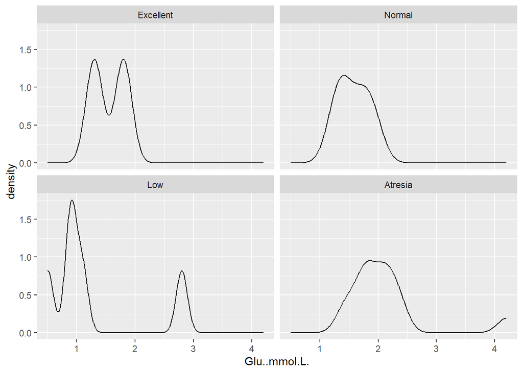

```r
ggplot(Ambient_Samples, aes(x = Glu..mmol.L.)) +
  geom_density(aes(x = Glu..mmol.L.)) +
  facet_wrap(~ Consensus_Brood_Condition)
```

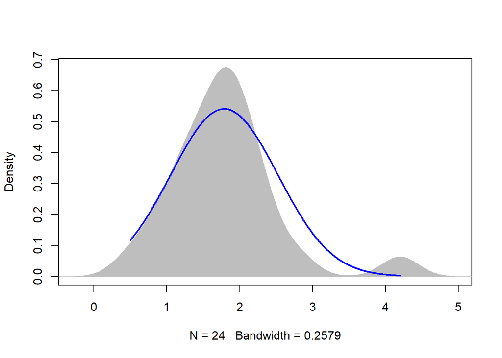

```r
plotNormalDensity(Ambient_Samples$Glu..mmol.L.)
```

Model Design:

[output not shown]

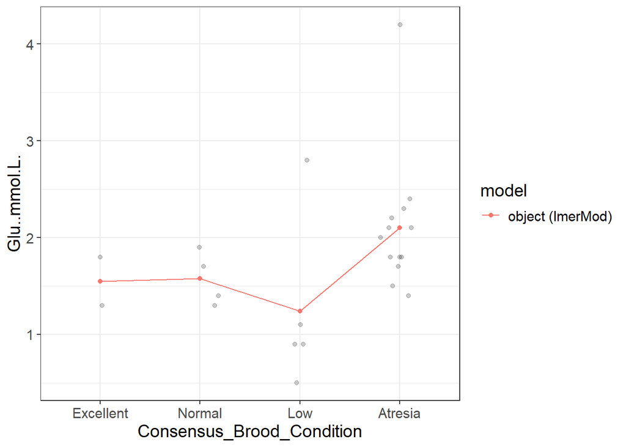

```r
# glucose ambient data

# Install flexplot
# devtools::install_github("dustinfife/flexplot", ref="development")
require(flexplot)

glucose_ambient_lmer <- lmer(Glu..mmol.L. ~ Consensus_Brood_Condition + (1|Consensus_Brood_Condition), data = Ambient_Samples)
visualize(glucose_ambient_lmer, plot = "model", sample = 50)
```

Normality Residual QQplot

```r
# Glucose
# Parametric Assumptions:

# Assessing Normality

# Summary of model
summary(glucose_ambient_lmer)
```

```
## Linear mixed model fit by REML. t-tests use Satterthwaite's method [
## lmerModLmerTest]
## Formula:
## Glu..mmol.L. ~ Consensus_Brood_Condition + (1 | Consensus_Brood_Condition)
##    Data: Ambient_Samples
##
## REML criterion at convergence: 49.3
##
## Scaled residuals:
##     Min      1Q  Median      3Q     Max
## -1.0780 -0.4516 -0.2294  0.2094  3.0592
##
## Random effects:
##  Groups                    Name        Variance Std.Dev.
##  Consensus_Brood_Condition (Intercept) 0.1531   0.3913
##  Residual                              0.4712   0.6865
## Number of obs: 24, groups:  Consensus_Brood_Condition, 4
##
## Fixed effects:
##                             Estimate Std. Error      df t value Pr(>|t|)
## (Intercept)                   1.6162     0.2618 20.0000   6.175 4.95e-06 ***
## Consensus_Brood_Condition.L   0.2940     0.5348 20.0000   0.550    0.589
## Consensus_Brood_Condition.Q   0.4175     0.5235 20.0000   0.797    0.435
## Consensus_Brood_Condition.C   0.3477     0.5120 20.0000   0.679    0.505
## ---
## Signif. codes:  0 '***' 0.001 '**' 0.01 '*' 0.05 '.' 0.1 ' ' 1
##
## Correlation of Fixed Effects:
##             (Intr) C_B_C.L C_B_C.Q
## Cnsns_B_C.L -0.248
## Cnsns_B_C.Q  0.055 -0.229
## Cnsns_B_C.C -0.054  0.033  -0.113
## optimizer (nloptwrap) convergence code: 0 (OK)
## unable to evaluate scaled gradient
##  Hessian is numerically singular: parameters are not uniquely determined
```

```r
# Suss residuals of model
glucose_ambient_res_lmer <- residuals(glucose_ambient_lmer)

# Shapiro test
shapiro.test(glucose_ambient_res_lmer)
```

```
##
##  Shapiro-Wilk normality test
##
## data:  glucose_ambient_res_lmer
## W = 0.76676, p-value = 8.838e-05
```

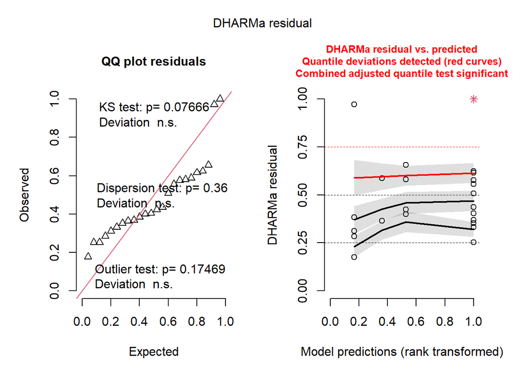

```r
# pH simulated residuals plot
glucose_ambient_simres_plot <- simulateResiduals(fittedModel = glucose_ambient_lmer)
plot(glucose_ambient_simres_plot)
```

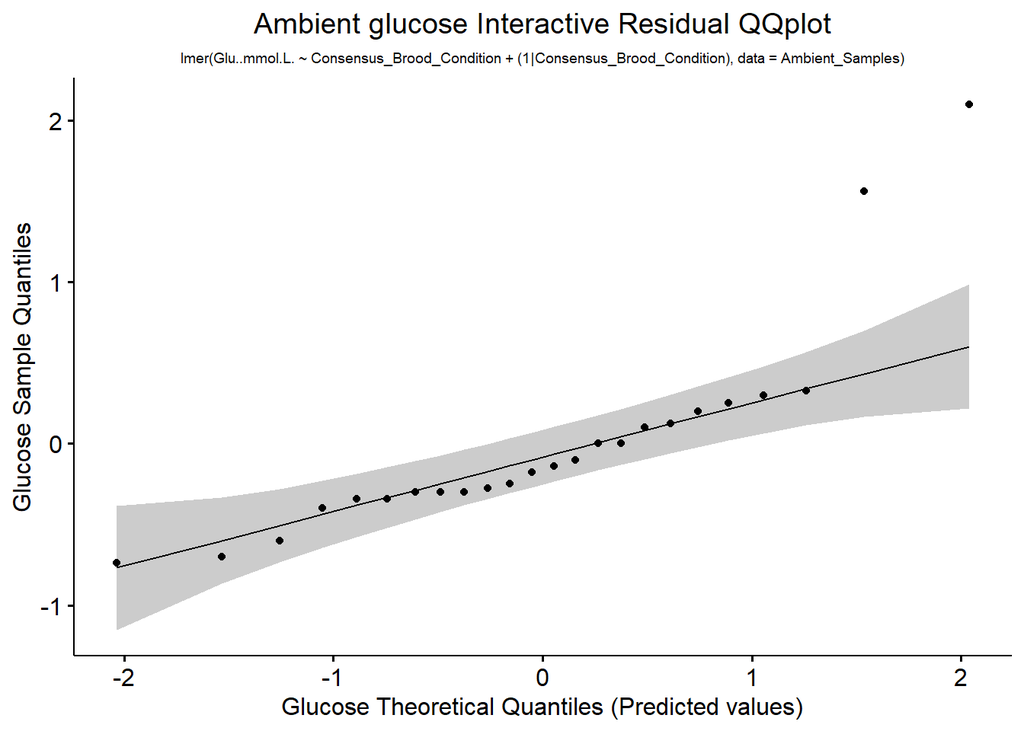

```r
# Qqplot of model
glucose_ambient_res_qqplot <- ggqqplot(residuals(glucose_ambient_lmer)) +
labs(title = "Ambient glucose Interactive Residual QQplot",
     subtitle = "lmer(Glu..mmol.L. ~ Consensus_Brood_Condition + (1|Consensus_Brood_Condition), data = Ambient_Samples)",
                               x = "Glucose Theoretical Quantiles (Predicted values)",
                               y = "Glucose Sample Quantiles") +
  theme(plot.title = element_text(hjust = 0.5),
        plot.subtitle = element_text(hjust = 0.5, size = 7))
print(glucose_ambient_res_qqplot)
```

```r
# ggsave(filename = "data-images/glucose_ambient_res_int_qqplot.pdf", plot = glucose_ambient_res_int_qqplot, device = "pdf")
# ggsave(filename = "data-images/glucose_ambient_res_int_qqplot.png", plot = glucose_ambient_res_int_qqplot, device = "png")
```

Glucose Parametric Assessment Testing Scedasticity:

```r
# glucose

# Ambient samples

# test with lmer
bartlett.test(glucose_ambient_res_lmer ~ Ambient_Samples$Consensus_Brood_Condition)
```

```
##
##  Bartlett test of homogeneity of variances
##
## data:  glucose_ambient_res_lmer by Ambient_Samples$Consensus_Brood_Condition
## Bartlett's K-squared = 3.6143, df = 3, p-value = 0.3062
```

```r
bartlett.test(Glu..mmol.L. ~ Consensus_Brood_Condition, Ambient_Samples)
```

```
##
##  Bartlett test of homogeneity of variances
##
## data:  Glu..mmol.L. by Consensus_Brood_Condition
## Bartlett's K-squared = 3.6143, df = 3, p-value = 0.3062
```

```r
# leveneTest(glucose ~ Consensus_Brood_Condition, Ambient_Samples)
```

Glucose Parametric Assumptions Assessment:

Warning: Check after assessing outliers

- Ambient Data normally distributed?
- Ambient Data equal variance across factors?

# Glucose Stat Tests

```r
# pH
# Ambient ANOVA Test

# Testing for differences in ambient parturition success metrics
# One-way ANOVA (parametric) or Kruskal-Wallis test (nonparametric)

glucose_aov_ambient <- aov(Glu..mmol.L. ~ Consensus_Brood_Condition, data = Ambient_Samples)
summary(glucose_aov_ambient)
```

```
##                           Df Sum Sq Mean Sq F value Pr(>F)
## Consensus_Brood_Condition  3  3.062  1.0206   2.166  0.124
## Residuals                 20  9.424  0.4712
```

```r
# If significant, Post Hoc Test:
# - Tukey's HSD (parametric, normality & equal variance across groups)
# - Dunn's test (non-parametric, after Kruskal-Wallis test)

TukeyHSD(glucose_aov_ambient)
```

```
##   Tukey multiple comparisons of means
##     95% family-wise confidence level
##
## Fit: aov(formula = Glu..mmol.L. ~ Consensus_Brood_Condition, data = Ambient_Samples)
##
## $Consensus_Brood_Condition
##                     diff        lwr       upr     p adj
## Normal-Excellent   0.025 -1.6389405 1.6889405 0.9999723
## Low-Excellent     -0.310 -1.9175192 1.2975192 0.9482180
## Atresia-Excellent  0.550 -0.9093723 2.0093723 0.7199378
## Low-Normal        -0.335 -1.6238827 0.9538827 0.8849375
## Atresia-Normal     0.525 -0.5735756 1.6235756 0.5509089
## Atresia-Low        0.860 -0.1510828 1.8710828 0.1134134
```

# Na+ : Sodium

Sodium Summary Stats

```r
# Na+
# Summary stats

# Ambient data
Ambient_Samples %>%
  group_by(Ambient.Or.OAH, Consensus_Brood_Condition) %>%
  summarize(count = n(),
            median = round(median(Na...mmol.L.), 3),
            mean = round(mean(Na...mmol.L.), 3),
            sd = round(sd(Na...mmol.L.), 3),
            cv = round(sd(Na...mmol.L.)/mean(Na...mmol.L.), 3)) %>%
  ungroup()
```

```
## # A tibble: 4 × 7
##   Ambient.Or.OAH Consensus_Brood_Condition count median  mean    sd    cv
##   <chr>          <ord>                     <int>  <dbl> <dbl> <dbl> <dbl>
## 1 Ambient        Excellent                     2   178   178   1.41 0.008
## 2 Ambient        Normal                        4   178.  177.  2.87 0.016
## 3 Ambient        Low                           5   176   176   5.34 0.03
## 4 Ambient        Atresia                      13   178   181. 11.4  0.063
```

Sodium Boxplot

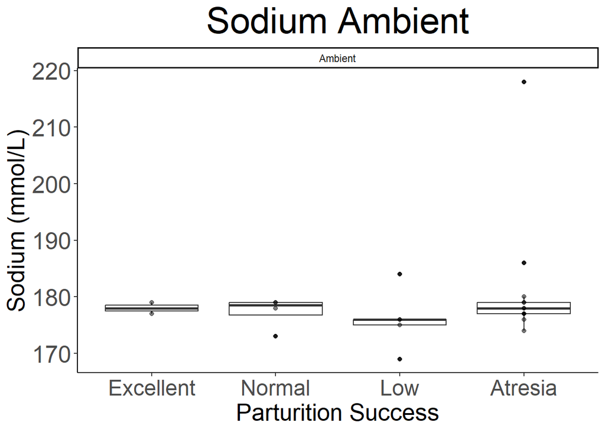

```r
# Na+ boxplot

# Ambient Samples
sodium_ambient_boxplot <- ggplot(data = Ambient_Samples) +
  geom_boxplot(aes(x = Consensus_Brood_Condition, y = Na...mmol.L.)) +
  geom_point(aes(x = Consensus_Brood_Condition, y = Na...mmol.L.), alpha = 0.5, colour = "black") +
  labs(title = "Sodium Ambient", x = "Parturition Success", y = "Sodium (mmol/L)") +
  facet_wrap(~ Ambient.Or.OAH) +
  theme_classic() +
  theme(panel.background = element_rect(fill = "white"),
        plot.background = element_rect(fill = "white"),
        legend.background = element_rect(fill = "white", color = "black"),
        title = element_text(size = 12),
        plot.title = element_text(size = 30, hjust = 0.5),
        axis.text.x = element_text(size = 18),
        axis.text.y = element_text(size = 20),
        axis.title.x = element_text(size = 20),
        axis.title.y = element_text(size = 20))

print(sodium_ambient_boxplot)
```

```r
ggsave(filename = "data-images/sodium_ambient_boxplot.pdf", plot = sodium_ambient_boxplot, device = "pdf")
ggsave(filename = "data-images/sodium_ambient_boxplot.png", plot = sodium_ambient_boxplot, device = "png")
```

Test Outliers

```r
# Na+
# Ambient

# Test outliers
```

Sodium Parametric Assessment Data Distribution

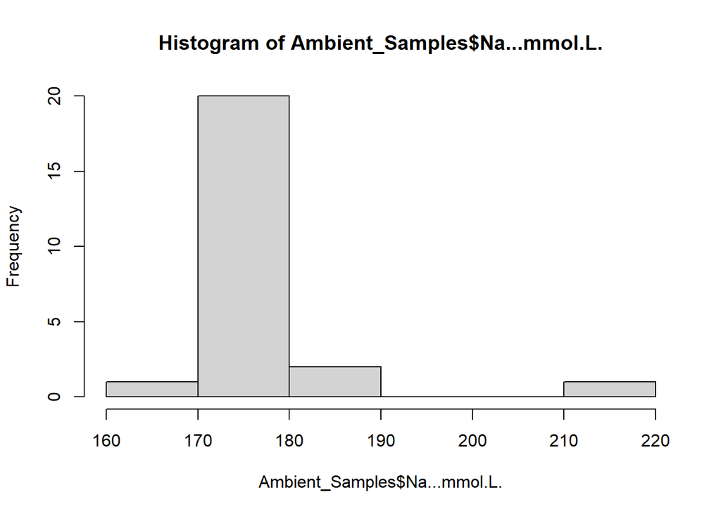

```r
# Na+
# Parametric Assumptions

# Data Distribution

# Frequency Histogram
hist(Ambient_Samples$Na...mmol.L.)
```

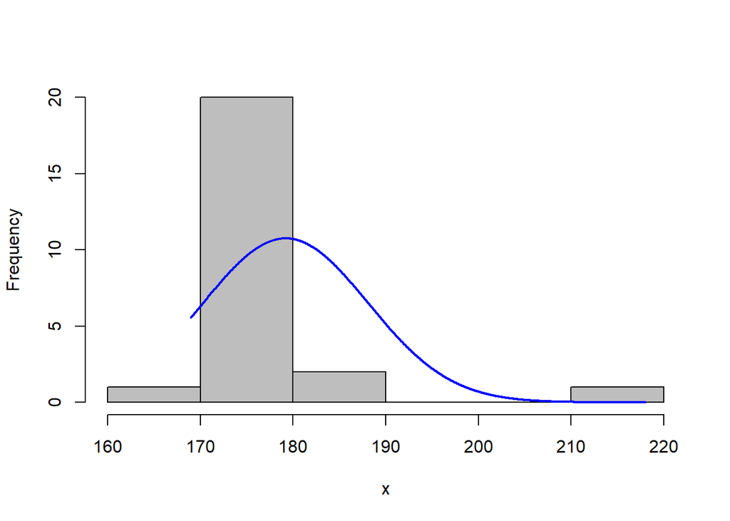

```r
plotNormalHistogram(Ambient_Samples$Na...mmol.L.)
```

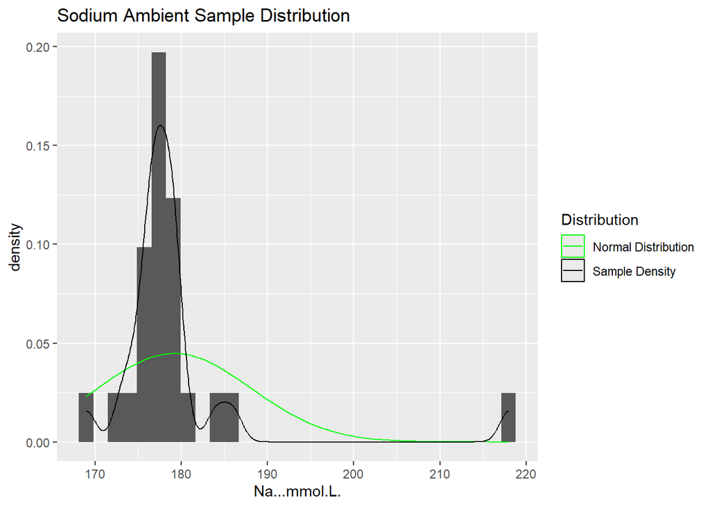

```r
# More accurate density curve?
Ambient_Samples %>%
  ggplot(aes(x = Na...mmol.L.)) +
  geom_histogram(aes(x = Na...mmol.L., y = after_stat(density))) +
  stat_function(fun = dnorm, args = c(mean = mean(Ambient_Samples$Na...mmol.L.), sd = sd(Ambient_Samples$Na...mmol.L.)), aes(col = "Normal Distribution"), show.legend = TRUE) +
  geom_density(aes(col = "Sample Density"), show.legend = TRUE) +
  labs(title = "Sodium Ambient Sample Distribution") +
  scale_color_manual("Distribution", values = c("Normal Distribution" = "green", "Sample Density" = "black"))
```

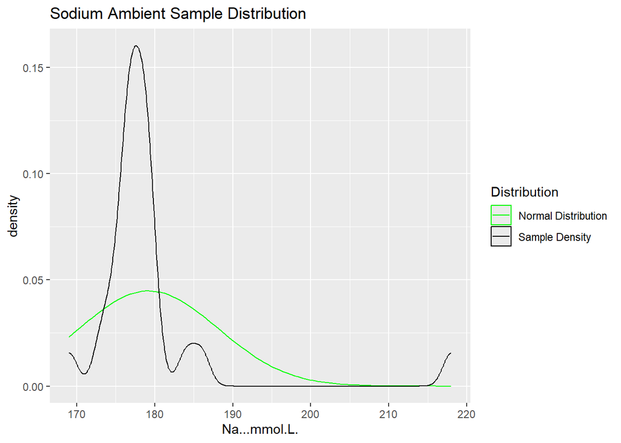

```r
# Density Plot with normal density
Ambient_Samples %>%
  ggplot(aes(x = Na...mmol.L.)) +
  stat_function(fun = dnorm, args = c(mean = mean(Ambient_Samples$Na...mmol.L.), sd = sd(Ambient_Samples$Na...mmol.L.)), aes(col = "Normal Distribution"), show.legend = TRUE) +
  geom_density(aes(col = "Sample Density"), show.legend = TRUE) +
  labs(title = "Sodium Ambient Sample Distribution") +
  scale_color_manual("Distribution", values = c("Normal Distribution" = "green", "Sample Density" = "black"))
```

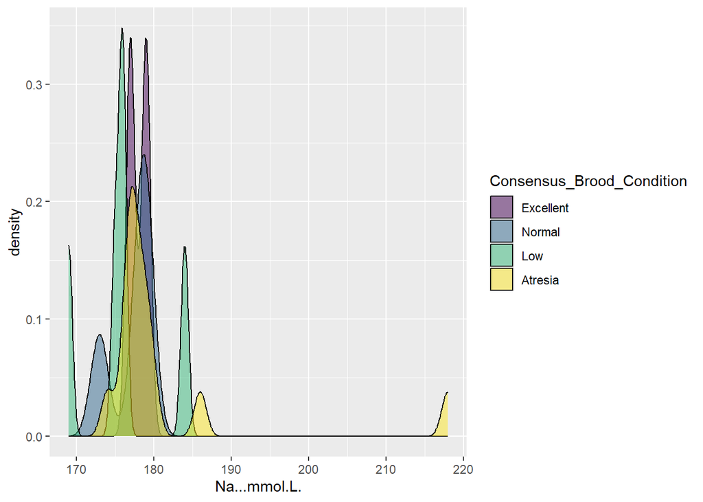

```r
# Density by brood condition
Ambient_Samples %>%
ggplot(aes(x = Na...mmol.L.)) +
  geom_density(aes(x = Na...mmol.L., fill = Consensus_Brood_Condition), alpha = 0.5)
```

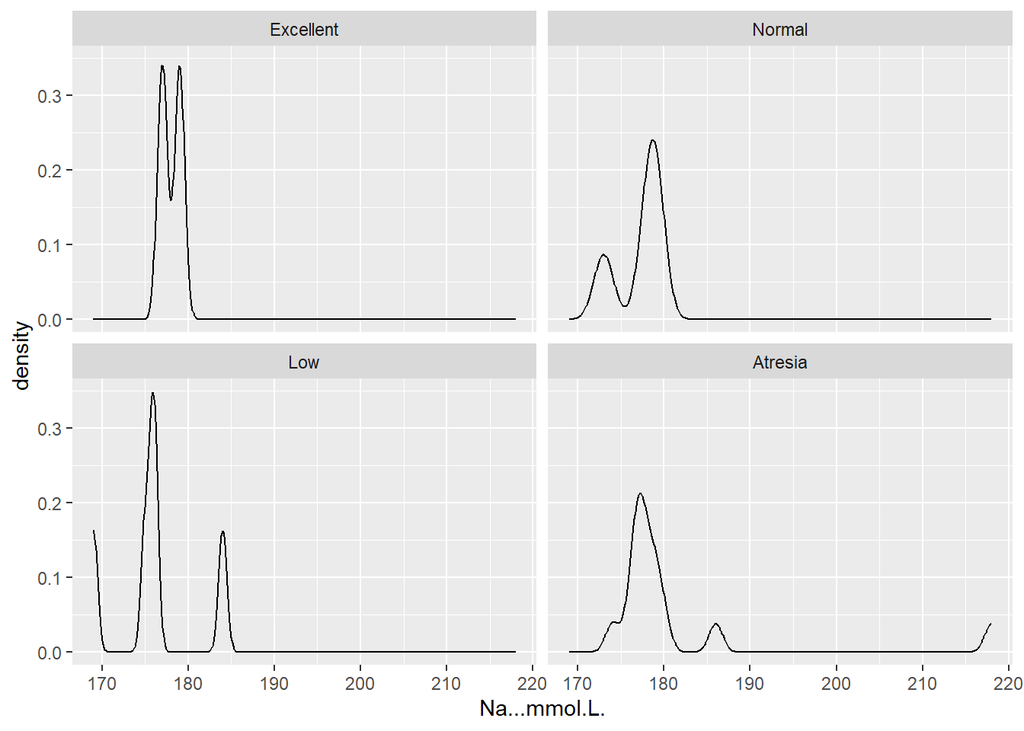

```r
ggplot(Ambient_Samples, aes(x = Na...mmol.L.)) +
  geom_density(aes(x = Na...mmol.L.)) +
  facet_wrap(~ Consensus_Brood_Condition)
```

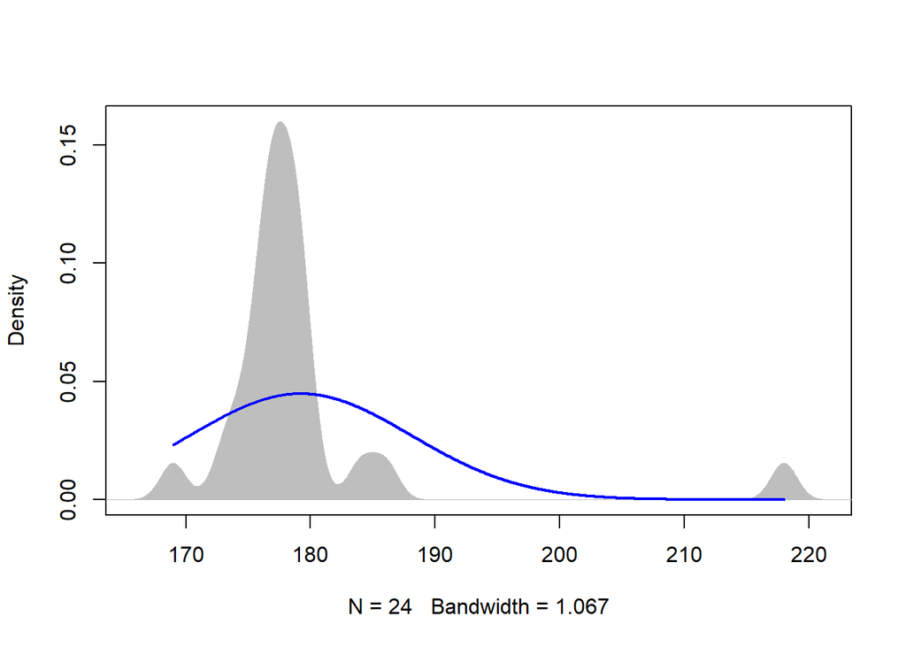

```r
plotNormalDensity(Ambient_Samples$Na...mmol.L.)
```

Model Design:

[output not shown]

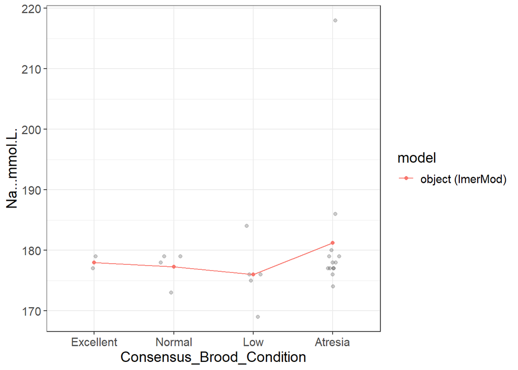

```r
# Na+ ambient data

# Install flexplot
# devtools::install_github("dustinfife/flexplot", ref="development")
require(flexplot)

sodium_ambient_lmer <- lmer(Na...mmol.L. ~ Consensus_Brood_Condition + (1|Consensus_Brood_Condition), data = Ambient_Samples)
visualize(sodium_ambient_lmer, plot = "model", sample = 50)
```

Normality Residual QQplot

```r
# Na+
# Parametric Assumptions:

# Assessing Normality

# Summary of model
summary(sodium_ambient_lmer)
```

```
## Linear mixed model fit by REML. t-tests use Satterthwaite's method [
## lmerModLmerTest]
## Formula:
## Na...mmol.L. ~ Consensus_Brood_Condition + (1 | Consensus_Brood_Condition)
##    Data: Ambient_Samples
##
## REML criterion at convergence: 153.2
##
## Scaled residuals:
##     Min      1Q  Median      3Q     Max
## -0.7845 -0.4590 -0.1878  0.0882  3.9893
##
## Random effects:
##  Groups                    Name        Variance Std.Dev.
##  Consensus_Brood_Condition (Intercept)  6.145   2.479
##  Residual                              84.953   9.217
## Number of obs: 24, groups:  Consensus_Brood_Condition, 4
##
## Fixed effects:
##                             Estimate Std. Error      df t value Pr(>|t|)
## (Intercept)                  178.120      2.644  20.000  67.377   <2e-16 ***
## Consensus_Brood_Condition.L    1.888      5.487  20.000   0.344    0.734
## Consensus_Brood_Condition.Q    2.990      5.287  20.000   0.566    0.578
## Consensus_Brood_Condition.C    1.561      5.079  20.000   0.307    0.762
## ---
## Signif. codes:  0 '***' 0.001 '**' 0.01 '*' 0.05 '.' 0.1 ' ' 1
##
## Correlation of Fixed Effects:
##             (Intr) C_B_C.L C_B_C.Q
## Cnsns_B_C.L -0.432
## Cnsns_B_C.Q  0.096 -0.399
## Cnsns_B_C.C -0.097  0.058  -0.203
## optimizer (nloptwrap) convergence code: 0 (OK)
## unable to evaluate scaled gradient
##  Hessian is numerically singular: parameters are not uniquely determined
```

```r
# Suss residuals of model
sodium_ambient_res_lmer <- residuals(sodium_ambient_lmer)

# Shapiro test
shapiro.test(sodium_ambient_res_lmer)
```

```
##
##  Shapiro-Wilk normality test
##
## data:  sodium_ambient_res_lmer
## W = 0.58592, p-value = 4.319e-07
```

```
## qu = 0.25, log(sigma) = -3.359911 : outer Newton did not converge fully.
```

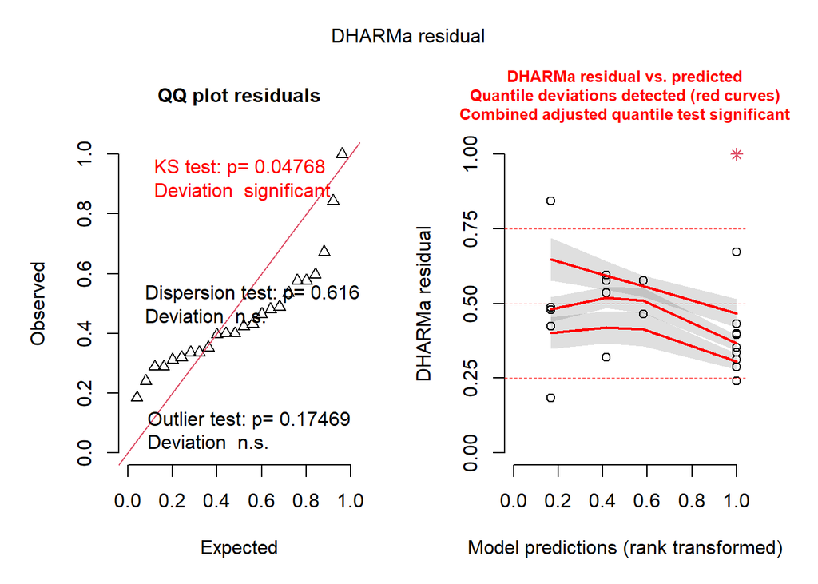

```r
# pH simulated residuals plot
sodium_ambient_simres_plot <- simulateResiduals(fittedModel = sodium_ambient_lmer)
plot(sodium_ambient_simres_plot)
```

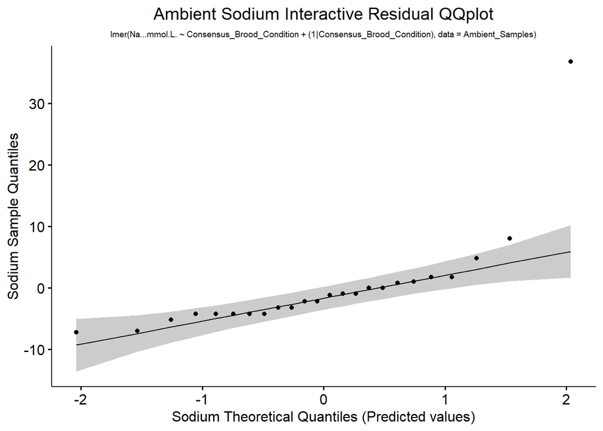

```r
# Qqplot of model
sodium_ambient_res_qqplot <- ggqqplot(residuals(sodium_ambient_lmer)) +
labs(title = "Ambient Sodium Interactive Residual QQplot",
     subtitle = "lmer(Na...mmol.L. ~ Consensus_Brood_Condition + (1|Consensus_Brood_Condition), data = Ambient_Samples)",
                               x = "Sodium Theoretical Quantiles (Predicted values)",
                               y = "Sodium Sample Quantiles") +
  theme(plot.title = element_text(hjust = 0.5),
        plot.subtitle = element_text(hjust = 0.5, size = 7))
print(sodium_ambient_res_qqplot)
```

```r
# ggsave(filename = "data-images/sodium_ambient_res_int_qqplot.pdf", plot = sodium_ambient_res_int_qqplot, device = "pdf")
# ggsave(filename = "data-images/sodium_ambient_res_int_qqplot.png", plot = sodium_ambient_res_int_qqplot, device = "png")
```

Sodium Parametric Assessment Testing Scedasticity:

```r
# Na+

# Ambient samples

# test with lmer
bartlett.test(sodium_ambient_res_lmer ~ Ambient_Samples$Consensus_Brood_Condition)
```

```
##
##  Bartlett test of homogeneity of variances
##
## data:  sodium_ambient_res_lmer by Ambient_Samples$Consensus_Brood_Condition
## Bartlett's K-squared = 8.4952, df = 3, p-value = 0.03681
```

```r
bartlett.test(Na...mmol.L. ~ Consensus_Brood_Condition, Ambient_Samples)
```

```
##
##  Bartlett test of homogeneity of variances
##
## data:  Na...mmol.L. by Consensus_Brood_Condition
## Bartlett's K-squared = 8.4952, df = 3, p-value = 0.03681
```

```r
# leveneTest(Na...mmol.L. ~ Consensus_Brood_Condition, Ambient_Samples)
```

Sodium Parametric Assumptions Assessment:

Warning: Check after assessing outliers

- Ambient Data normally distributed?
- Ambient Data equal variance across factors?

# Na+ Stat Tests

```r
# Na+
# Ambient ANOVA Test

# Testing for differences in ambient parturition success metrics
# One-way ANOVA (parametric) or Kruskal-Wallis test (nonparametric)

sodium_aov_ambient <- aov(Na...mmol.L. ~ Consensus_Brood_Condition, data = Ambient_Samples)
summary(sodium_aov_ambient)
```

```
##                           Df Sum Sq Mean Sq F value Pr(>F)
## Consensus_Brood_Condition  3  122.9   40.97   0.482  0.698
## Residuals                 20 1699.1   84.95
```

```r
# If significant, Post Hoc Test:
# - Tukey's HSD (parametric, normality & equal variance across groups)
# - Dunn's test (non-parametric, after Kruskal-Wallis test)

TukeyHSD(sodium_aov_ambient)
```

```
##   Tukey multiple comparisons of means
##     95% family-wise confidence level
##
## Fit: aov(formula = Na...mmol.L. ~ Consensus_Brood_Condition, data = Ambient_Samples)
##
## $Consensus_Brood_Condition
##                        diff        lwr      upr     p adj
## Normal-Excellent  -0.750000 -23.091519 21.59152 0.9996922
## Low-Excellent     -2.000000 -23.583957 19.58396 0.9936875
## Atresia-Excellent  3.230769 -16.364039 22.82558 0.9665624
## Low-Normal        -1.250000 -18.555666 16.05567 0.9969760
## Atresia-Normal     3.980769 -10.769666 18.73120 0.8733094
## Atresia-Low        5.230769  -8.344912 18.80645 0.7062405
```

Sodium Ambient Results

Which brood condition significantly different (if any)?

# Cl- : Chloride

Chloride Summary Stats

```r
# Cl-
# Summary stats

# Ambient data
Ambient_Samples %>%
  group_by(Ambient.Or.OAH, Consensus_Brood_Condition) %>%
  summarize(count = n(),
            median = round(median(Cl...mmol.L.), 3),
            mean = round(mean(Cl...mmol.L.), 3),
            sd = round(sd(Cl...mmol.L.), 3),
            cv = round(sd(Cl...mmol.L.)/mean(Cl...mmol.L.), 3)) %>%
  ungroup()
```

```
## # A tibble: 4 × 7
##   Ambient.Or.OAH Consensus_Brood_Condition count median  mean    sd    cv
##   <chr>          <ord>                     <int>  <dbl> <dbl> <dbl> <dbl>
## 1 Ambient        Excellent                     2    161  161   4.24 0.026
## 2 Ambient        Normal                        4    160  159.  3.86 0.024
## 3 Ambient        Low                           5    156  154.  3.05 0.02
## 4 Ambient        Atresia                      13    158  158.  4.61 0.029
```

Chloride Boxplot

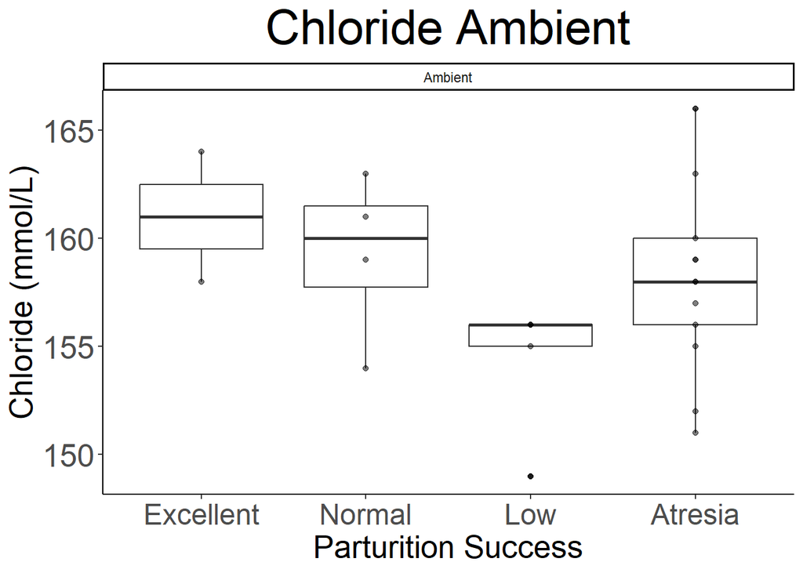

```r
# Cl- boxplot

# Ambient Samples
chloride_ambient_boxplot <- ggplot(data = Ambient_Samples) +
  geom_boxplot(aes(x = Consensus_Brood_Condition, y = Cl...mmol.L.)) +
  geom_point(aes(x = Consensus_Brood_Condition, y = Cl...mmol.L.), alpha = 0.5, colour = "black") +
  labs(title = "Chloride Ambient", x = "Parturition Success", y = "Chloride (mmol/L)") +
  facet_wrap(~ Ambient.Or.OAH) +
  theme_classic() +
  theme(panel.background = element_rect(fill = "white"),
        plot.background = element_rect(fill = "white"),
        legend.background = element_rect(fill = "white", color = "black"),
        title = element_text(size = 12),
        plot.title = element_text(size = 30, hjust = 0.5),
        axis.text.x = element_text(size = 18),
        axis.text.y = element_text(size = 20),
        axis.title.x = element_text(size = 20),
        axis.title.y = element_text(size = 20))

print(chloride_ambient_boxplot)
```

```r
ggsave(filename = "data-images/chloride_ambient_boxplot.pdf", plot = chloride_ambient_boxplot, device = "pdf")
ggsave(filename = "data-images/chloride_ambient_boxplot.png", plot = chloride_ambient_boxplot, device = "png")
```

Chloride Parametric Assessment Data Distribution

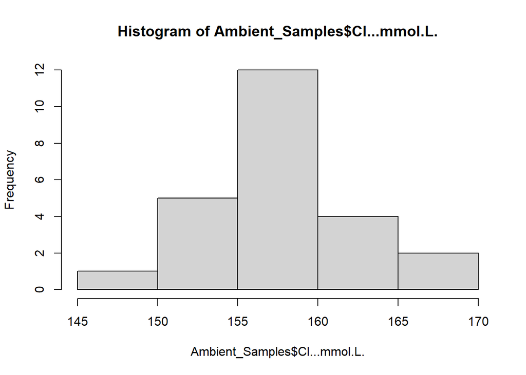

```r
# Cl-
# Parametric Assumptions

# Data Distribution

# Frequency Histogram
hist(Ambient_Samples$Cl...mmol.L.)
```

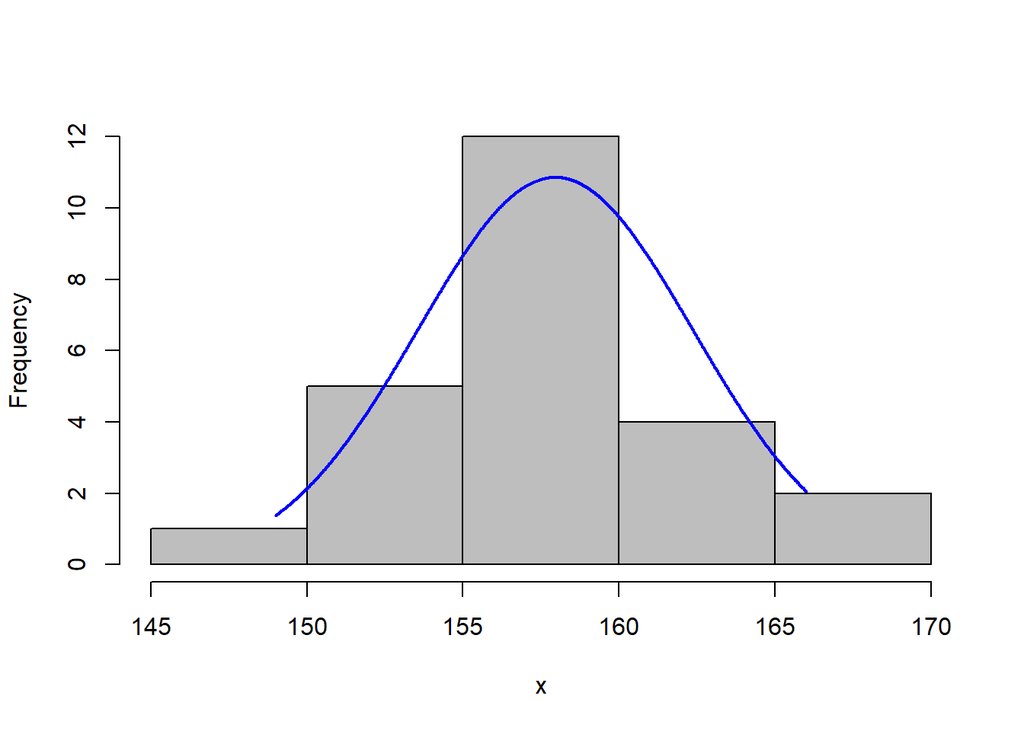

```r
plotNormalHistogram(Ambient_Samples$Cl...mmol.L.)
```

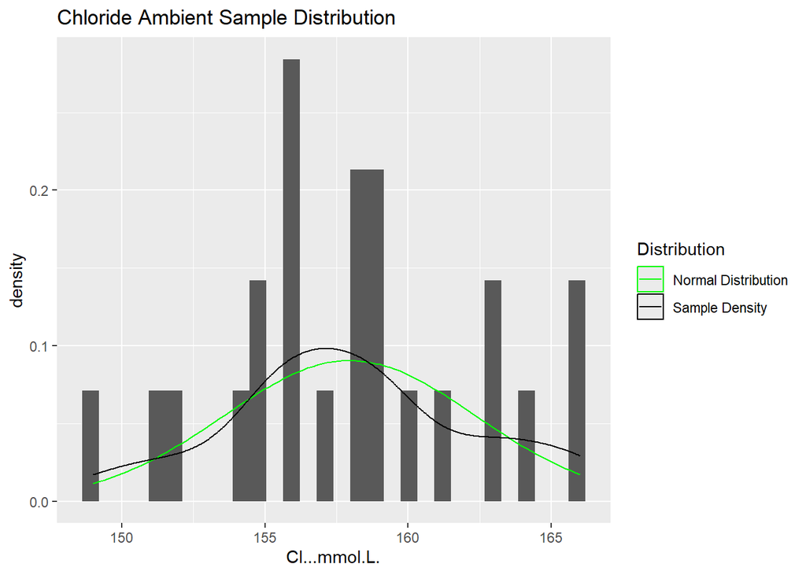

```r
# More accurate density curve?
Ambient_Samples %>%
  ggplot(aes(x = Cl...mmol.L.)) +
  geom_histogram(aes(x = Cl...mmol.L., y = after_stat(density))) +
  stat_function(fun = dnorm, args = c(mean = mean(Ambient_Samples$Cl...mmol.L.), sd = sd(Ambient_Samples$Cl...mmol.L.)), aes(col = "Normal Distribution"), show.legend = TRUE) +
  geom_density(aes(col = "Sample Density"), show.legend = TRUE) +
  labs(title = "Chloride Ambient Sample Distribution") +
  scale_color_manual("Distribution", values = c("Normal Distribution" = "green", "Sample Density" = "black"))
```

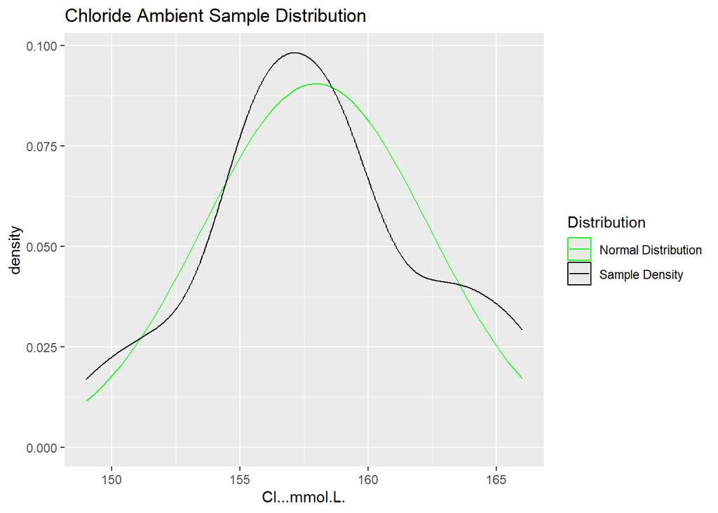

```r
# Density Plot with normal density
Ambient_Samples %>%
  ggplot(aes(x = Cl...mmol.L.)) +
  stat_function(fun = dnorm, args = c(mean = mean(Ambient_Samples$Cl...mmol.L.), sd = sd(Ambient_Samples$Cl...mmol.L.)), aes(col = "Normal Distribution"), show.legend = TRUE) +
  geom_density(aes(col = "Sample Density"), show.legend = TRUE) +
  labs(title = "Chloride Ambient Sample Distribution") +
  scale_color_manual("Distribution", values = c("Normal Distribution" = "green", "Sample Density" = "black"))
```

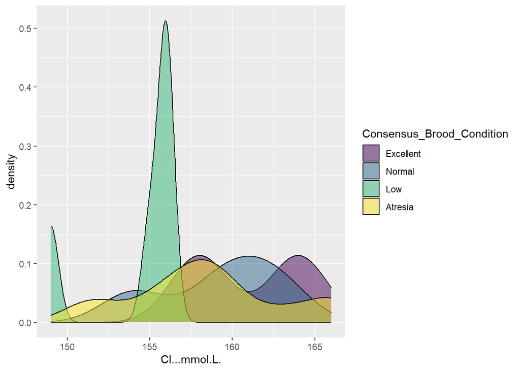

```r
# Density by brood condition
Ambient_Samples %>%
ggplot(aes(x = Cl...mmol.L.)) +
  geom_density(aes(x = Cl...mmol.L., fill = Consensus_Brood_Condition), alpha = 0.5)
```

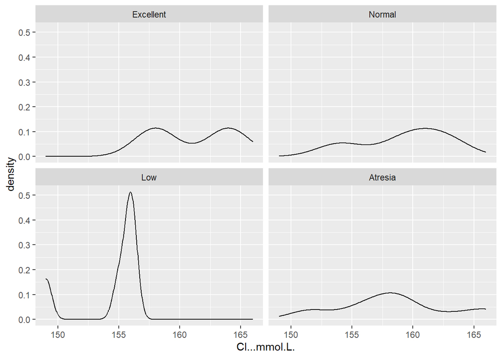

```r
ggplot(Ambient_Samples, aes(x = Cl...mmol.L.)) +
  geom_density(aes(x = Cl...mmol.L.)) +
  facet_wrap(~ Consensus_Brood_Condition)
```

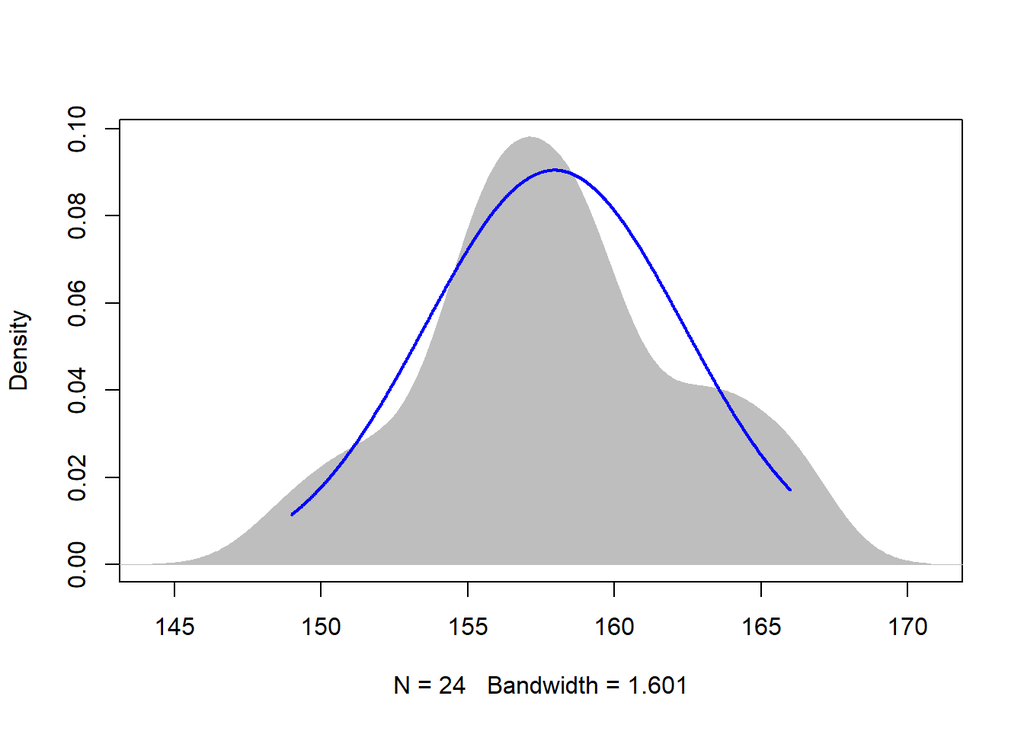

```r
plotNormalDensity(Ambient_Samples$Cl...mmol.L.)
```

Model Design:

[output not shown]

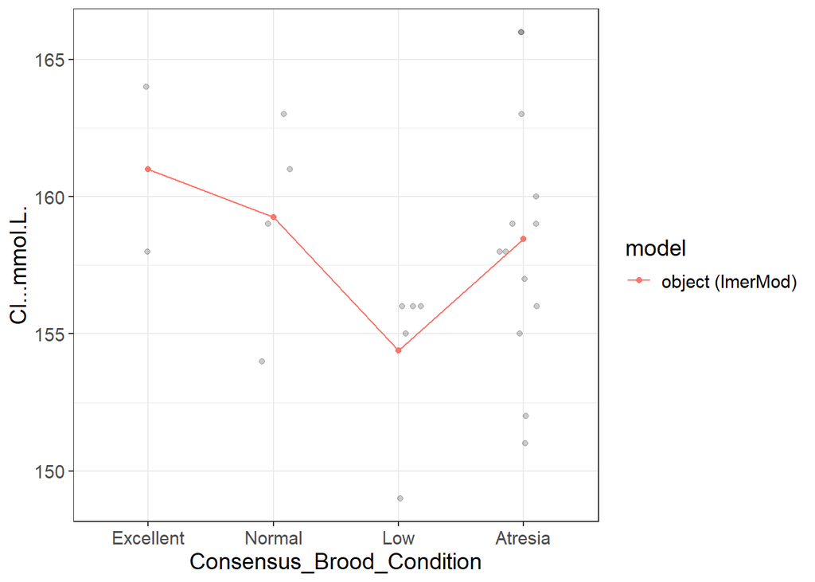

```r
# Cl- ambient data

# Install flexplot
# devtools::install_github("dustinfife/flexplot", ref="development")
require(flexplot)

chloride_ambient_lmer <- lmer(Cl...mmol.L. ~ Consensus_Brood_Condition + (1|Consensus_Brood_Condition), data = Ambient_Samples)
visualize(chloride_ambient_lmer, plot = "model", sample = 50)
```

Normality Residual QQplot

```r
# Cl-
# Parametric Assumptions:

# Assessing Normality

# Summary of model
summary(chloride_ambient_lmer)
```

```
## Linear mixed model fit by REML. t-tests use Satterthwaite's method [
## lmerModLmerTest]
## Formula:
## Cl...mmol.L. ~ Consensus_Brood_Condition + (1 | Consensus_Brood_Condition)
##    Data: Ambient_Samples
##
## REML criterion at convergence: 121.9
##
## Scaled residuals:
##     Min      1Q  Median      3Q     Max
## -1.7706 -0.6161  0.1278  0.3886  1.7889
##
## Random effects:
##  Groups                    Name        Variance Std.Dev.
##  Consensus_Brood_Condition (Intercept)  4.596   2.144
##  Residual                              17.759   4.214
## Number of obs: 24, groups:  Consensus_Brood_Condition, 4
##
## Fixed effects:
##                             Estimate Std. Error      df t value Pr(>|t|)
## (Intercept)                  158.278      1.513  20.000 104.621   <2e-16 ***
## Consensus_Brood_Condition.L   -2.787      3.099  20.000  -0.899    0.379
## Consensus_Brood_Condition.Q    2.906      3.026  20.000   0.960    0.348
## Consensus_Brood_Condition.C    2.686      2.950  20.000   0.910    0.373
## ---
## Signif. codes:  0 '***' 0.001 '**' 0.01 '*' 0.05 '.' 0.1 ' ' 1
##
## Correlation of Fixed Effects:
##             (Intr) C_B_C.L C_B_C.Q
## Cnsns_B_C.L -0.279
## Cnsns_B_C.Q  0.062 -0.258
## Cnsns_B_C.C -0.061  0.037  -0.127
## optimizer (nloptwrap) convergence code: 0 (OK)
## unable to evaluate scaled gradient
##  Hessian is numerically singular: parameters are not uniquely determined
```

```r
# Suss residuals of model
chloride_ambient_res_lmer <- residuals(chloride_ambient_lmer)

# Shapiro test
shapiro.test(chloride_ambient_res_lmer)
```

```
##
##  Shapiro-Wilk normality test
##
## data:  chloride_ambient_res_lmer
## W = 0.96846, p-value = 0.6292
```

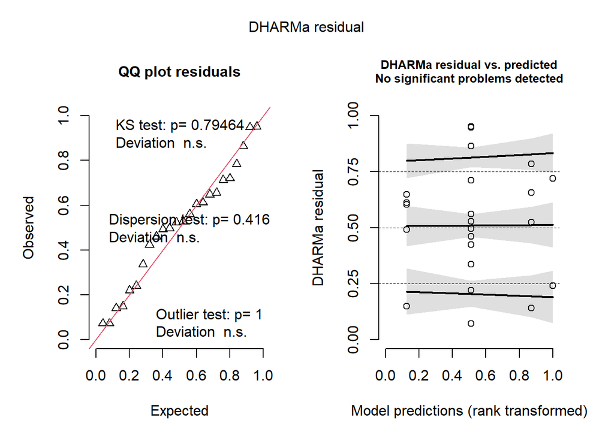

```r
# pH simulated residuals plot
chloride_ambient_simres_plot <- simulateResiduals(fittedModel = chloride_ambient_lmer)
plot(chloride_ambient_simres_plot)
```

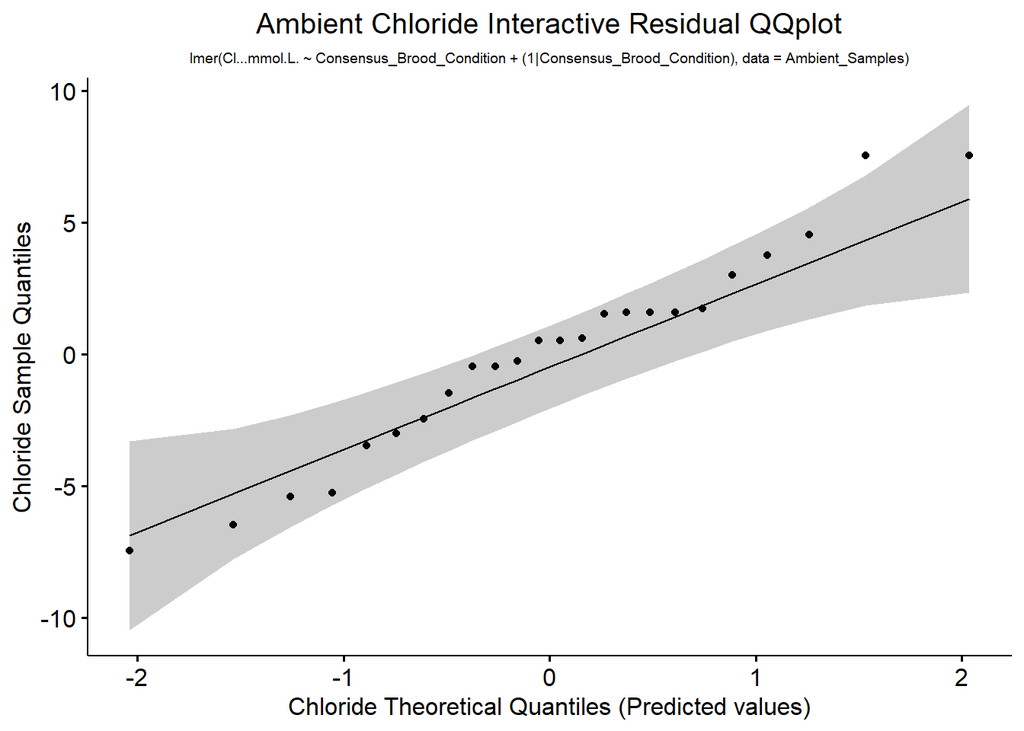

```r
# Qqplot of model
chloride_ambient_res_qqplot <- ggqqplot(residuals(chloride_ambient_lmer)) +
labs(title = "Ambient Chloride Interactive Residual QQplot",
     subtitle = "lmer(Cl...mmol.L. ~ Consensus_Brood_Condition + (1|Consensus_Brood_Condition), data = Ambient_Samples)",
                               x = "Chloride Theoretical Quantiles (Predicted values)",
                               y = "Chloride Sample Quantiles") +
  theme(plot.title = element_text(hjust = 0.5),
        plot.subtitle = element_text(hjust = 0.5, size = 7))
print(chloride_ambient_res_qqplot)
```

```r
# ggsave(filename = "data-images/chloride_ambient_res_int_qqplot.pdf", plot = chloride_ambient_res_int_qqplot, device = "pdf")
# ggsave(filename = "data-images/chloride_ambient_res_int_qqplot.png", plot = chloride_ambient_res_int_qqplot, device = "png")
```

Chloride Parametric Assessment Testing Scedasticity:

```r
# Cl-

# Ambient samples

# test with lmer
bartlett.test(chloride_ambient_res_lmer ~ Ambient_Samples$Consensus_Brood_Condition)
```

```
##
##  Bartlett test of homogeneity of variances
##
## data:  chloride_ambient_res_lmer by Ambient_Samples$Consensus_Brood_Condition
## Bartlett's K-squared = 0.79083, df = 3, p-value = 0.8517
```

```r
bartlett.test(Cl...mmol.L. ~ Consensus_Brood_Condition, Ambient_Samples)
```

```
##
##  Bartlett test of homogeneity of variances
##
## data:  Cl...mmol.L. by Consensus_Brood_Condition
## Bartlett's K-squared = 0.79083, df = 3, p-value = 0.8517
```

```r
# leveneTest(Cl...mmol.L. ~ Consensus_Brood_Condition, Ambient_Samples)
```

Chloride Parametric Assumptions Assessment:

Warning: Check after assessing outliers

- Ambient Data normally distributed?
- Ambient Data equal variance across factors?

# Cl- Stat Tests

```r
# Cl-
# Ambient ANOVA Test

# Testing for differences in ambient parturition success metrics
# One-way ANOVA (parametric) or Kruskal-Wallis test (nonparametric)

chloride_aov_ambient <- aov(Cl...mmol.L. ~ Consensus_Brood_Condition, data = Ambient_Samples)
summary(chloride_aov_ambient)
```

```
##                           Df Sum Sq Mean Sq F value Pr(>F)
## Consensus_Brood_Condition  3   91.8   30.59   1.723  0.195
## Residuals                 20  355.2   17.76
```

```r
# If significant, Post Hoc Test:
# - Tukey's HSD (parametric, normality & equal variance across groups)
# - Dunn's test (non-parametric, after Kruskal-Wallis test)

TukeyHSD(chloride_aov_ambient)
```

```
##   Tukey multiple comparisons of means
##     95% family-wise confidence level
##
## Fit: aov(formula = Cl...mmol.L. ~ Consensus_Brood_Condition, data = Ambient_Samples)
##
## $Consensus_Brood_Condition
##                         diff        lwr       upr     p adj
## Normal-Excellent  -1.7500000 -11.964882  8.464882 0.9627546
## Low-Excellent     -6.6000000 -16.468513  3.268513 0.2711600
## Atresia-Excellent -2.5384615 -11.497506  6.420582 0.8567438
## Low-Normal        -4.8500000 -12.762413  3.062413 0.3420231
## Atresia-Normal    -0.7884615  -7.532585  5.955662 0.9875346
## Atresia-Low        4.0615385  -2.145469 10.268546 0.2884665
```

Chloride Ambient Results

Which brood condition significantly different (if any)?

# K+ : Potassium

Potassium Summary Stats

```r
# K+
# Summary stats

# Ambient data
Ambient_Samples %>%
  group_by(Ambient.Or.OAH, Consensus_Brood_Condition) %>%
  summarize(count = n(),
            median = round(median(K...mmol.L.), 3),
            mean = round(mean(K...mmol.L.), 3),
            sd = round(sd(K...mmol.L.), 3),
            cv = round(sd(K...mmol.L.)/mean(K...mmol.L.), 3)) %>%
  ungroup()
```

```
## # A tibble: 4 × 7
##   Ambient.Or.OAH Consensus_Brood_Condition count median  mean    sd    cv
##   <chr>          <ord>                     <int>  <dbl> <dbl> <dbl> <dbl>
## 1 Ambient        Excellent                     2    2.6  2.6  0.141 0.054
## 2 Ambient        Normal                        4    2.7  2.7  0.082 0.03
## 3 Ambient        Low                           5    2.8  2.78 0.192 0.069
## 4 Ambient        Atresia                      13    2.7  2.86 0.304 0.106
```

Potassium Boxplot

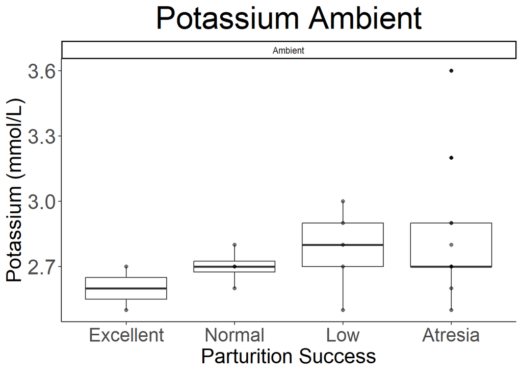

```r
# K+ boxplot

# Ambient Samples
potassium_ambient_boxplot <- ggplot(data = Ambient_Samples) +
  geom_boxplot(aes(x = Consensus_Brood_Condition, y = K...mmol.L.)) +
  geom_point(aes(x = Consensus_Brood_Condition, y = K...mmol.L.), alpha = 0.5, colour = "black") +
  labs(title = "Potassium Ambient", x = "Parturition Success", y = "Potassium (mmol/L)") +
  facet_wrap(~ Ambient.Or.OAH) +
  theme_classic() +
  theme(panel.background = element_rect(fill = "white"),
        plot.background = element_rect(fill = "white"),
        legend.background = element_rect(fill = "white", color = "black"),
        title = element_text(size = 12),
        plot.title = element_text(size = 30, hjust = 0.5),
        axis.text.x = element_text(size = 18),
        axis.text.y = element_text(size = 20),
        axis.title.x = element_text(size = 20),
        axis.title.y = element_text(size = 20))

print(potassium_ambient_boxplot)
```

```r
ggsave(filename = "data-images/potassium_ambient_boxplot.pdf", plot = potassium_ambient_boxplot, device = "pdf")
ggsave(filename = "data-images/potassium_ambient_boxplot.png", plot = potassium_ambient_boxplot, device = "png")
```

Test Outliers

```r
# Na+
# Ambient

# Test outliers
```

Potassium Parametric Assessment Data Distribution

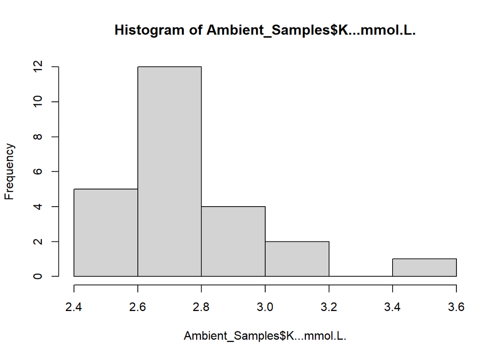

```r
# K+
# Parametric Assumptions

# Data Distribution

# Frequency Histogram
hist(Ambient_Samples$K...mmol.L.)
```

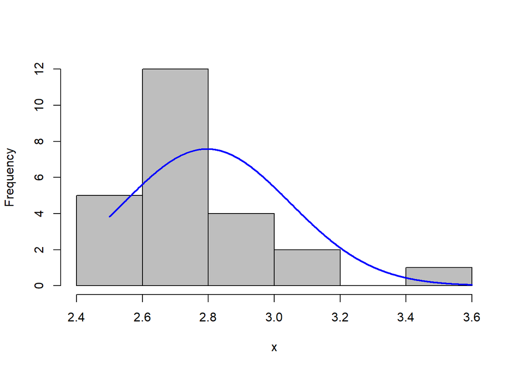

```r
plotNormalHistogram(Ambient_Samples$K...mmol.L.)
```

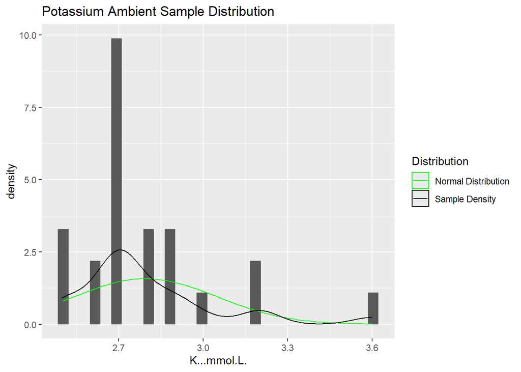

```r
# More accurate density curve?
Ambient_Samples %>%
  ggplot(aes(x = K...mmol.L.)) +
  geom_histogram(aes(x = K...mmol.L., y = after_stat(density))) +
  stat_function(fun = dnorm, args = c(mean = mean(Ambient_Samples$K...mmol.L.), sd = sd(Ambient_Samples$K...mmol.L.)), aes(col = "Normal Distribution"), show.legend = TRUE) +
  geom_density(aes(col = "Sample Density"), show.legend = TRUE) +
  labs(title = "Potassium Ambient Sample Distribution") +
  scale_color_manual("Distribution", values = c("Normal Distribution" = "green", "Sample Density" = "black"))
```

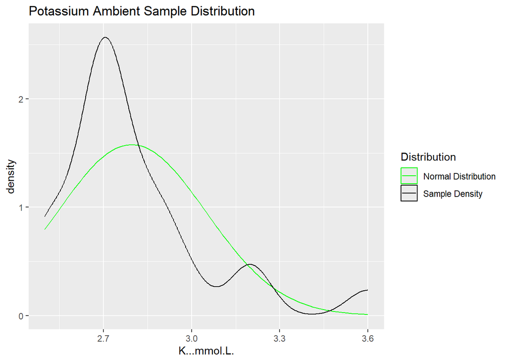

```r
# Density Plot with normal density
Ambient_Samples %>%
  ggplot(aes(x = K...mmol.L.)) +
  stat_function(fun = dnorm, args = c(mean = mean(Ambient_Samples$K...mmol.L.), sd = sd(Ambient_Samples$K...mmol.L.)), aes(col = "Normal Distribution"), show.legend = TRUE) +
  geom_density(aes(col = "Sample Density"), show.legend = TRUE) +
  labs(title = "Potassium Ambient Sample Distribution") +
  scale_color_manual("Distribution", values = c("Normal Distribution" = "green", "Sample Density" = "black"))
```

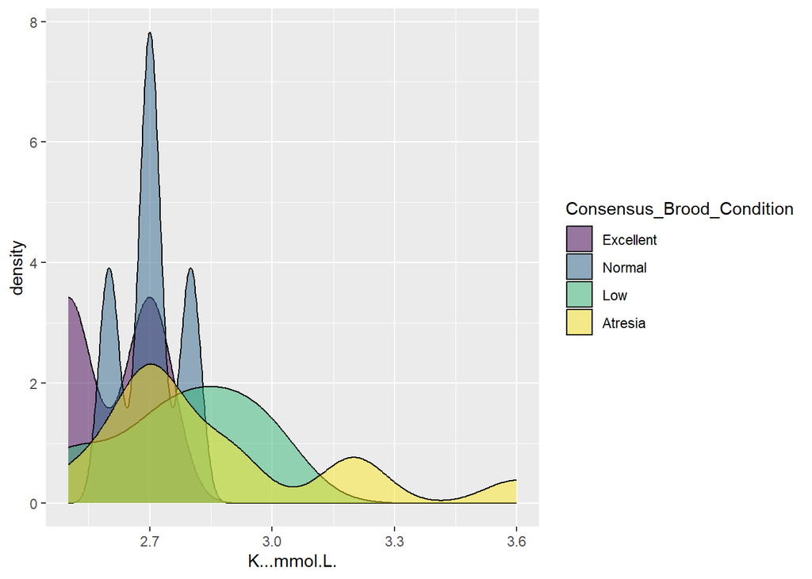

```r
# Density by brood condition
Ambient_Samples %>%
ggplot(aes(x = K...mmol.L.)) +
  geom_density(aes(x = K...mmol.L., fill = Consensus_Brood_Condition), alpha = 0.5)
```

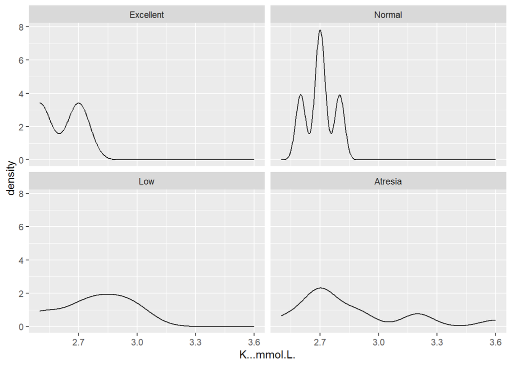

```r
ggplot(Ambient_Samples, aes(x = K...mmol.L.)) +
  geom_density(aes(x = K...mmol.L.)) +
  facet_wrap(~ Consensus_Brood_Condition)
```

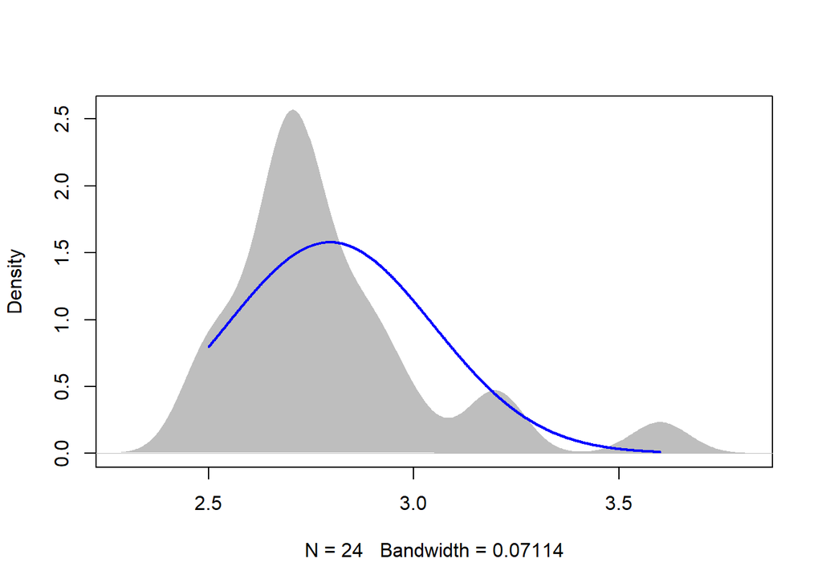

```r
plotNormalDensity(Ambient_Samples$K...mmol.L.)
```

Model Design:

[output not shown]

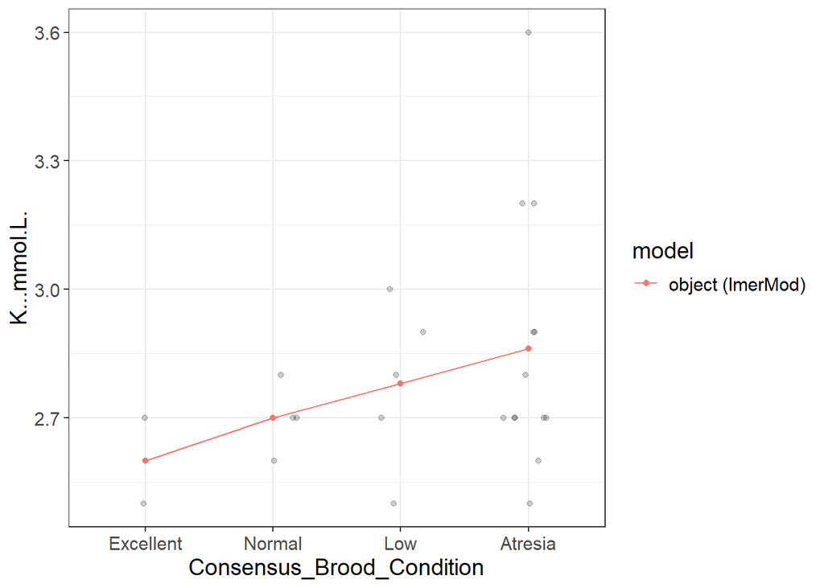

```r
# K+ ambient data

# Install flexplot
# devtools::install_github("dustinfife/flexplot", ref="development")
require(flexplot)

potassium_ambient_lmer <- lmer(K...mmol.L. ~ Consensus_Brood_Condition + (1|Consensus_Brood_Condition), data = Ambient_Samples)
visualize(potassium_ambient_lmer, plot = "model", sample = 50)
```

Normality Residual QQplot

```r
# K+
# Parametric Assumptions:

# Assessing Normality

# Summary of model
summary(potassium_ambient_lmer)
```

```
## Linear mixed model fit by REML. t-tests use Satterthwaite's method [
## lmerModLmerTest]
## Formula:
## K...mmol.L. ~ Consensus_Brood_Condition + (1 | Consensus_Brood_Condition)
##    Data: Ambient_Samples
##
## REML criterion at convergence: 9.7
##
## Scaled residuals:
##     Min      1Q  Median      3Q     Max
## -1.4187 -0.6339 -0.1207  0.3924  2.8979
##
## Random effects:
##  Groups                    Name        Variance Std.Dev.
##  Consensus_Brood_Condition (Intercept) 0.008413 0.09172
##  Residual                              0.064938 0.25483
## Number of obs: 24, groups:  Consensus_Brood_Condition, 4
##
## Fixed effects:
##                              Estimate Std. Error        df t value Pr(>|t|)
## (Intercept)                  2.735385   0.079191 20.000000  34.542   <2e-16 ***
## Consensus_Brood_Condition.L  0.193334   0.163503 20.000000   1.182    0.251
## Consensus_Brood_Condition.Q -0.009231   0.158382 20.000000  -0.058    0.954
## Consensus_Brood_Condition.C  0.004816   0.153089 20.000000   0.031    0.975
## ---
## Signif. codes:  0 '***' 0.001 '**' 0.01 '*' 0.05 '.' 0.1 ' ' 1
##
## Correlation of Fixed Effects:
##             (Intr) C_B_C.L C_B_C.Q
## Cnsns_B_C.L -0.370
## Cnsns_B_C.Q  0.082 -0.342
## Cnsns_B_C.C -0.082  0.049  -0.172
## optimizer (nloptwrap) convergence code: 0 (OK)
##  Hessian is numerically singular: parameters are not uniquely determined
```

```r
# Suss residuals of model
potassium_ambient_res_lmer <- residuals(potassium_ambient_lmer)

# Shapiro test
shapiro.test(potassium_ambient_res_lmer)
```

```
##
##  Shapiro-Wilk normality test
##
## data:  potassium_ambient_res_lmer
## W = 0.90438, p-value = 0.02669
```

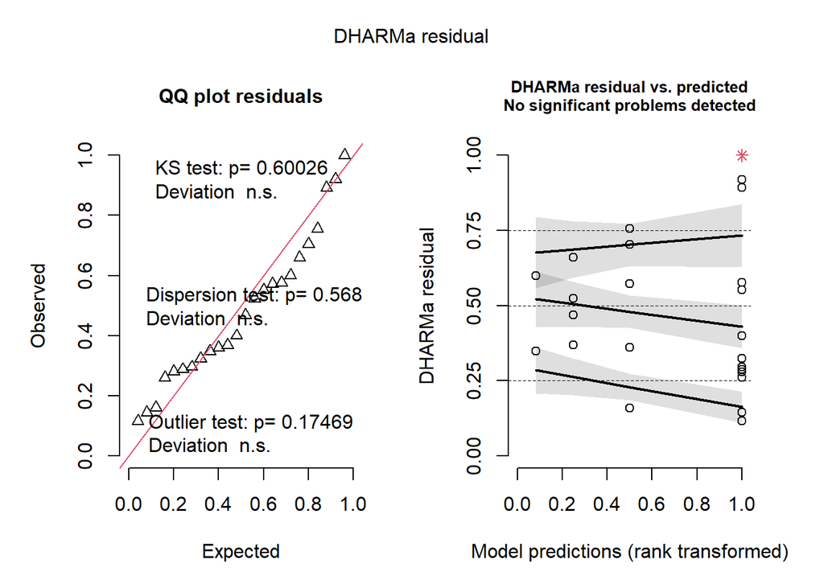

```r
# pH simulated residuals plot
potassium_ambient_simres_plot <- simulateResiduals(fittedModel = potassium_ambient_lmer)
plot(potassium_ambient_simres_plot)
```

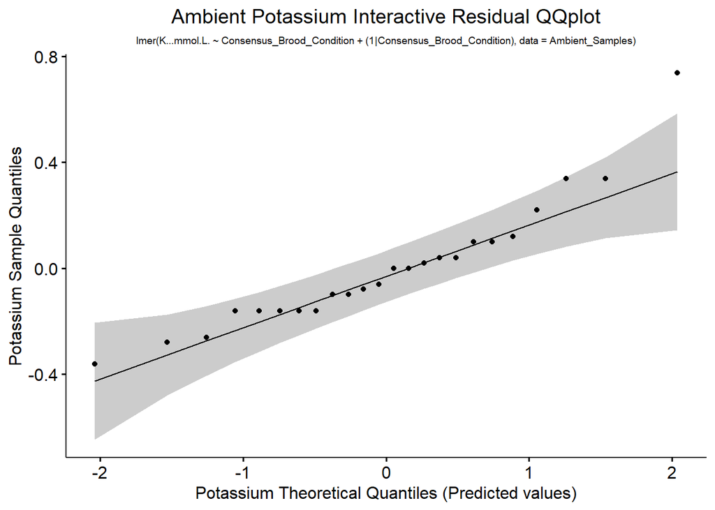

```r
# Qqplot of model
potassium_ambient_res_qqplot <- ggqqplot(residuals(potassium_ambient_lmer)) +
labs(title = "Ambient Potassium Interactive Residual QQplot",
     subtitle = "lmer(K...mmol.L. ~ Consensus_Brood_Condition + (1|Consensus_Brood_Condition), data = Ambient_Samples)",
                               x = "Potassium Theoretical Quantiles (Predicted values)",
                               y = "Potassium Sample Quantiles") +
  theme(plot.title = element_text(hjust = 0.5),
        plot.subtitle = element_text(hjust = 0.5, size = 7))
print(potassium_ambient_res_qqplot)
```

```r
# ggsave(filename = "data-images/potassium_ambient_res_int_qqplot.pdf", plot = potassium_ambient_res_int_qqplot, device = "pdf")
# ggsave(filename = "data-images/potassium_ambient_res_int_qqplot.png", plot = potassium_ambient_res_int_qqplot, device = "png")
```

Potassium Parametric Assessment Testing Scedasticity:

```r
# K+

# Ambient samples

# test with lmer
bartlett.test(potassium_ambient_res_lmer ~ Ambient_Samples$Consensus_Brood_Condition)
```

```
##
##  Bartlett test of homogeneity of variances
##
## data:  potassium_ambient_res_lmer by Ambient_Samples$Consensus_Brood_Condition
## Bartlett's K-squared = 5.0891, df = 3, p-value = 0.1654
```

```r
bartlett.test(K...mmol.L. ~ Consensus_Brood_Condition, Ambient_Samples)
```

```
##
##  Bartlett test of homogeneity of variances
##
## data:  K...mmol.L. by Consensus_Brood_Condition
## Bartlett's K-squared = 5.0891, df = 3, p-value = 0.1654
```

```r
# leveneTest(K...mmol.L. ~ Consensus_Brood_Condition, Ambient_Samples)
```

Potassium Parametric Assumptions Assessment:

Warning: Check after assessing outliers

- Ambient Data normally distributed?
- Ambient Data equal variance across factors?

# K+ Stat Tests

```r
# K+
# Ambient ANOVA Test

# Testing for differences in ambient parturition success metrics
# One-way ANOVA (parametric) or Kruskal-Wallis test (nonparametric)

potassium_aov_ambient <- aov(K...mmol.L. ~ Consensus_Brood_Condition, data = Ambient_Samples)
summary(potassium_aov_ambient)
```

```
##                           Df Sum Sq Mean Sq F value Pr(>F)
## Consensus_Brood_Condition  3 0.1708 0.05694   0.877   0.47
## Residuals                 20 1.2988 0.06494
```

```r
# If significant, Post Hoc Test:
# - Tukey's HSD (parametric, normality & equal variance across groups)
# - Dunn's test (non-parametric, after Kruskal-Wallis test)

TukeyHSD(potassium_aov_ambient)
```

```
##   Tukey multiple comparisons of means
##     95% family-wise confidence level
##
## Fit: aov(formula = K...mmol.L. ~ Consensus_Brood_Condition, data = Ambient_Samples)
##
## $Consensus_Brood_Condition
##                         diff        lwr       upr     p adj
## Normal-Excellent  0.10000000 -0.5176958 0.7176958 0.9682454
## Low-Excellent     0.18000000 -0.4167508 0.7767508 0.8327769
## Atresia-Excellent 0.26153846 -0.2802166 0.8032935 0.5427545
## Low-Normal        0.08000000 -0.3984651 0.5584651 0.9652175
## Atresia-Normal    0.16153846 -0.2462799 0.5693568 0.6884912
## Atresia-Low       0.08153846 -0.2938004 0.4568773 0.9283278
```

Potassium Ambient Results

Which brood condition significantly different (if any)?

# Ca+2 : Calcium

Calcium Summary Stats

```r
# Ca+2
# Summary stats

# Ambient data
Ambient_Samples %>%
  group_by(Ambient.Or.OAH, Consensus_Brood_Condition) %>%
  summarize(count = n(),
            median = round(median(Ca....mmol.L.), 3),
            mean = round(mean(Ca....mmol.L.), 3),
            sd = round(sd(Ca....mmol.L.), 3),
            cv = round(sd(Ca....mmol.L.)/mean(Ca....mmol.L.), 3)) %>%
  ungroup()
```

```
## # A tibble: 4 × 7
##   Ambient.Or.OAH Consensus_Brood_Condition count median  mean    sd    cv
##   <chr>          <ord>                     <int>  <dbl> <dbl> <dbl> <dbl>
## 1 Ambient        Excellent                     2   1.38  1.38 0.12  0.087
## 2 Ambient        Normal                        4   1.42  1.43 0.05  0.035
## 3 Ambient        Low                           5   1.38  1.39 0.051 0.037
## 4 Ambient        Atresia                      13   1.24  1.27 0.114 0.09
```

Calcium Boxplot

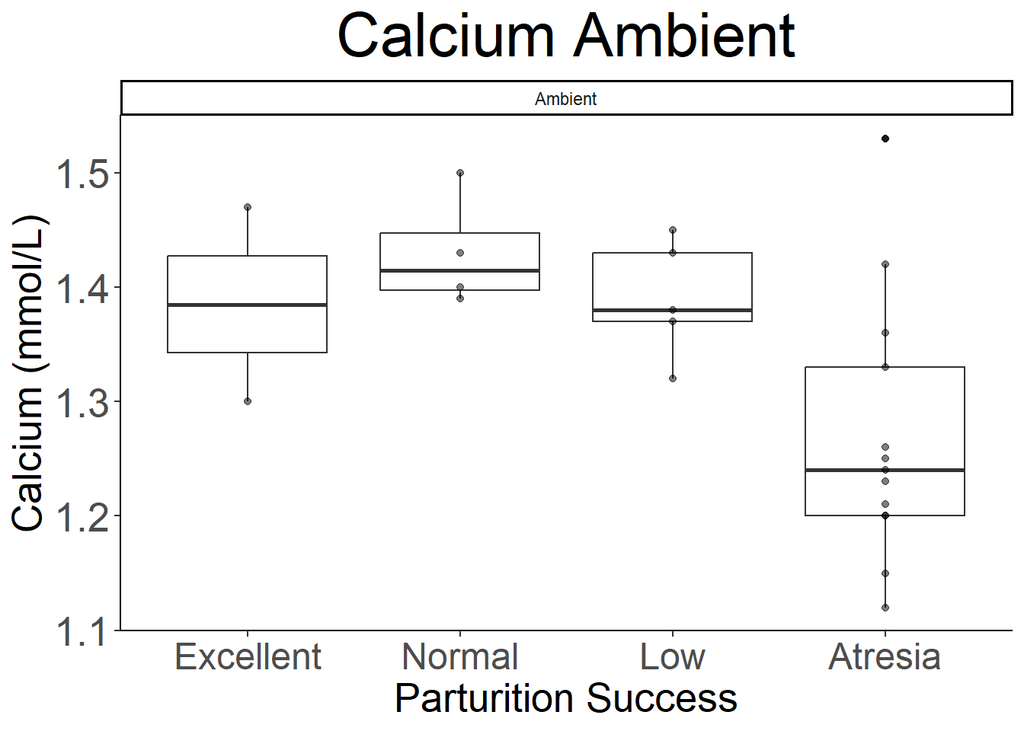

```r
# Ca+2 boxplot

# Ambient Samples
calcium_ambient_boxplot <- ggplot(data = Ambient_Samples) +
  geom_boxplot(aes(x = Consensus_Brood_Condition, y = Ca....mmol.L.)) +
  geom_point(aes(x = Consensus_Brood_Condition, y = Ca....mmol.L.), alpha = 0.5, colour = "black") +
  labs(title = "Calcium Ambient", x = "Parturition Success", y = "Calcium (mmol/L)") +
  facet_wrap(~ Ambient.Or.OAH) +
  theme_classic() +
  theme(panel.background = element_rect(fill = "white"),
        plot.background = element_rect(fill = "white"),
        legend.background = element_rect(fill = "white", color = "black"),
        title = element_text(size = 12),
        plot.title = element_text(size = 30, hjust = 0.5),
        axis.text.x = element_text(size = 18),
        axis.text.y = element_text(size = 20),
        axis.title.x = element_text(size = 20),
        axis.title.y = element_text(size = 20))

print(calcium_ambient_boxplot)
```

```r
ggsave(filename = "data-images/calcium_ambient_boxplot.pdf", plot = calcium_ambient_boxplot, device = "pdf")
ggsave(filename = "data-images/calcium_ambient_boxplot.png", plot = calcium_ambient_boxplot, device = "png")
```

Test Outliers

```r
# Na+
# Ambient

# Test outliers
```

Calcium Parametric Assessment Data Distribution

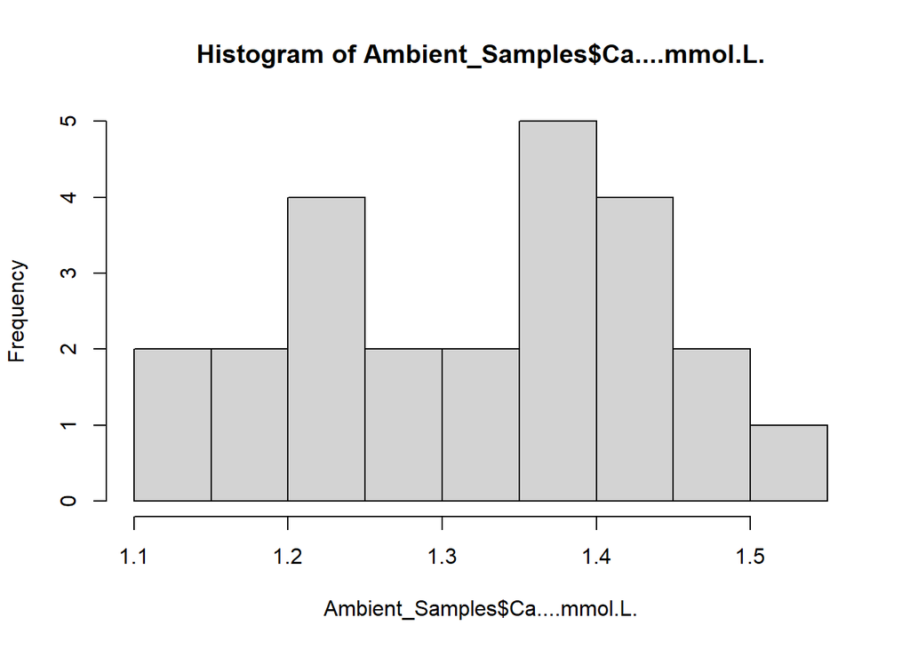

```r
# Ca+2
# Parametric Assumptions

# Data Distribution

# Frequency Histogram
hist(Ambient_Samples$Ca....mmol.L.)
```

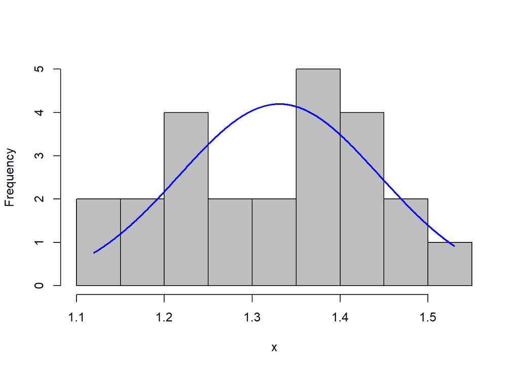

```r
plotNormalHistogram(Ambient_Samples$Ca....mmol.L.)
```

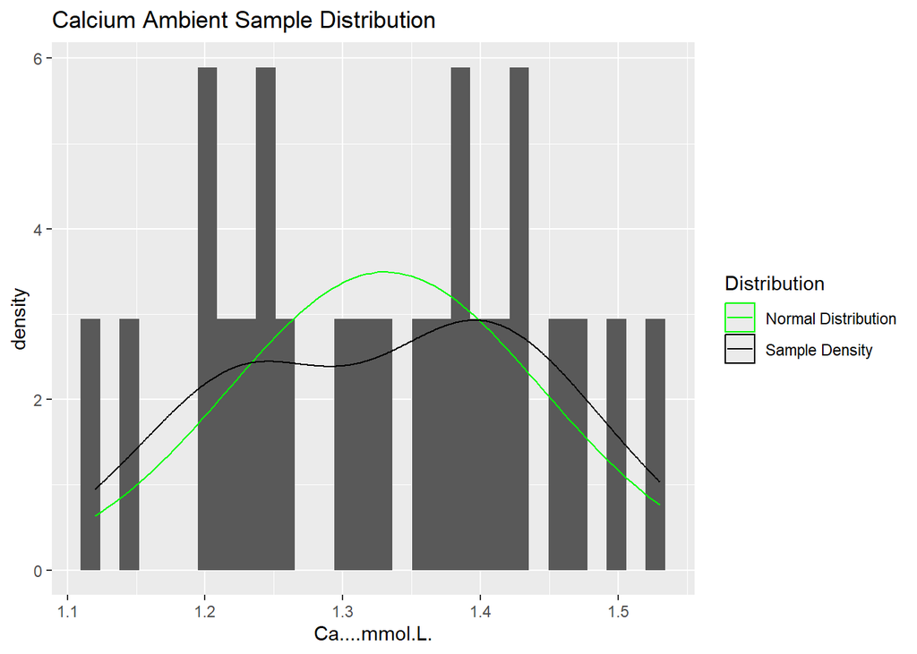

```r
# More accurate density curve?
Ambient_Samples %>%
  ggplot(aes(x = Ca....mmol.L.)) +
  geom_histogram(aes(x = Ca....mmol.L., y = after_stat(density))) +
  stat_function(fun = dnorm, args = c(mean = mean(Ambient_Samples$Ca....mmol.L.), sd = sd(Ambient_Samples$Ca....mmol.L.)), aes(col = "Normal Distribution"), show.legend = TRUE) +
  geom_density(aes(col = "Sample Density"), show.legend = TRUE) +
  labs(title = "Calcium Ambient Sample Distribution") +
  scale_color_manual("Distribution", values = c("Normal Distribution" = "green", "Sample Density" = "black"))
```

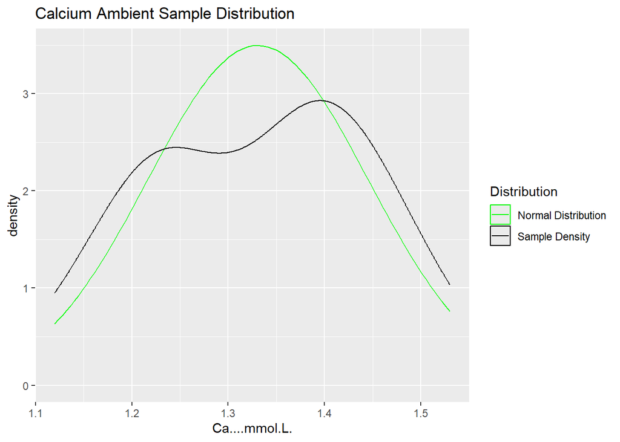

```r
# Density Plot with normal density
Ambient_Samples %>%
  ggplot(aes(x = Ca....mmol.L.)) +
  stat_function(fun = dnorm, args = c(mean = mean(Ambient_Samples$Ca....mmol.L.), sd = sd(Ambient_Samples$Ca....mmol.L.)), aes(col = "Normal Distribution"), show.legend = TRUE) +
  geom_density(aes(col = "Sample Density"), show.legend = TRUE) +
  labs(title = "Calcium Ambient Sample Distribution") +
  scale_color_manual("Distribution", values = c("Normal Distribution" = "green", "Sample Density" = "black"))
```

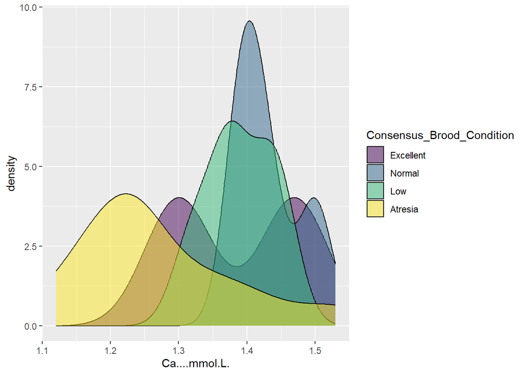

```r
# Density by brood condition
Ambient_Samples %>%
ggplot(aes(x = Ca....mmol.L.)) +
  geom_density(aes(x = Ca....mmol.L., fill = Consensus_Brood_Condition), alpha = 0.5)
```

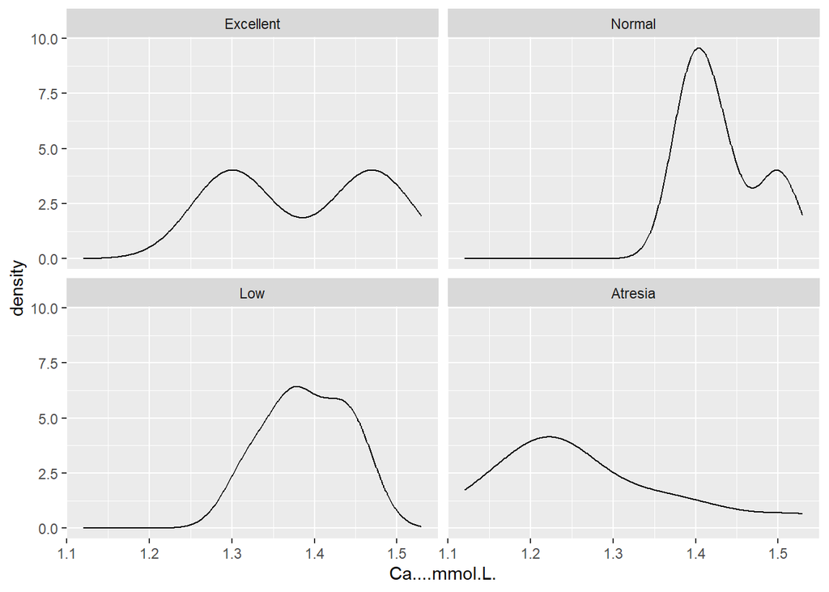

```r
ggplot(Ambient_Samples, aes(x = Ca....mmol.L.)) +
  geom_density(aes(x = Ca....mmol.L.)) +
  facet_wrap(~ Consensus_Brood_Condition)
```

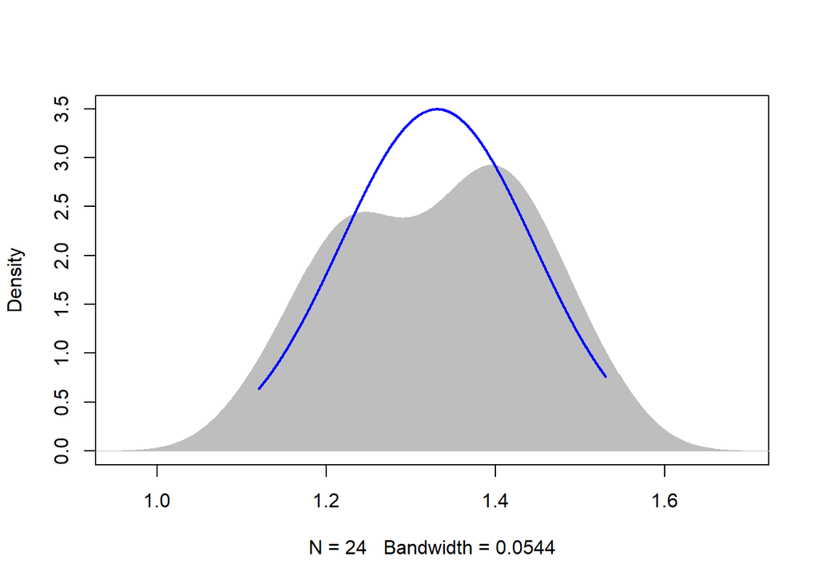

```r
plotNormalDensity(Ambient_Samples$Ca....mmol.L.)
```

Model Design:

[output not shown]

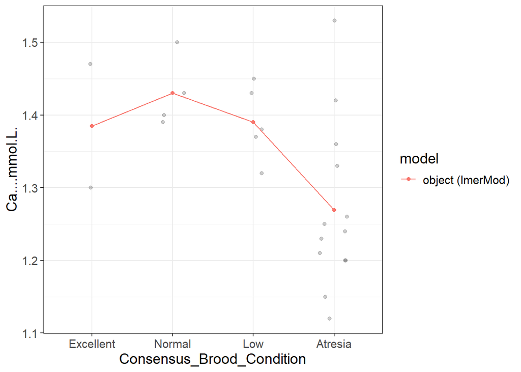

```r
# Ca+2 ambient data

# Install flexplot
# devtools::install_github("dustinfife/flexplot", ref="development")
require(flexplot)

calcium_ambient_lmer <- lmer(Ca....mmol.L. ~ Consensus_Brood_Condition + (1|Consensus_Brood_Condition), data = Ambient_Samples)
visualize(calcium_ambient_lmer, plot = "model", sample = 50)
```

Normality Residual QQplot

```r
# Ca+2
# Parametric Assumptions:

# Assessing Normality

# Summary of model
summary(calcium_ambient_lmer)
```

```
## Linear mixed model fit by REML. t-tests use Satterthwaite's method [
## lmerModLmerTest]
## Formula:
## Ca....mmol.L. ~ Consensus_Brood_Condition + (1 | Consensus_Brood_Condition)
##    Data: Ambient_Samples
##
## REML criterion at convergence: -29
##
## Scaled residuals:
##     Min      1Q  Median      3Q     Max
## -1.5411 -0.6375 -0.2026  0.6216  2.6929
##
## Random effects:
##  Groups                    Name        Variance Std.Dev.
##  Consensus_Brood_Condition (Intercept) 0.006474 0.08046
##  Residual                              0.009377 0.09684
## Number of obs: 24, groups:  Consensus_Brood_Condition, 4
##
## Fixed effects:
##                              Estimate Std. Error        df t value Pr(>|t|)
## (Intercept)                  1.368558   0.047120 20.000000  29.044   <2e-16 ***
## Consensus_Brood_Condition.L -0.086605   0.095495 20.000000  -0.907    0.375
## Consensus_Brood_Condition.Q -0.082885   0.094241 20.000000  -0.880    0.390
## Consensus_Brood_Condition.C  0.000946   0.092969 20.000000   0.010    0.992
## ---
## Signif. codes:  0 '***' 0.001 '**' 0.01 '*' 0.05 '.' 0.1 ' ' 1
##
## Correlation of Fixed Effects:
##             (Intr) C_B_C.L C_B_C.Q
## Cnsns_B_C.L -0.154
## Cnsns_B_C.Q  0.034 -0.142
## Cnsns_B_C.C -0.033  0.020  -0.069
```

```r
# Suss residuals of model
calcium_ambient_res_lmer <- residuals(calcium_ambient_lmer)

# Shapiro test
shapiro.test(calcium_ambient_res_lmer)
```

```
##
##  Shapiro-Wilk normality test
##
## data:  calcium_ambient_res_lmer
## W = 0.93341, p-value = 0.1162
```

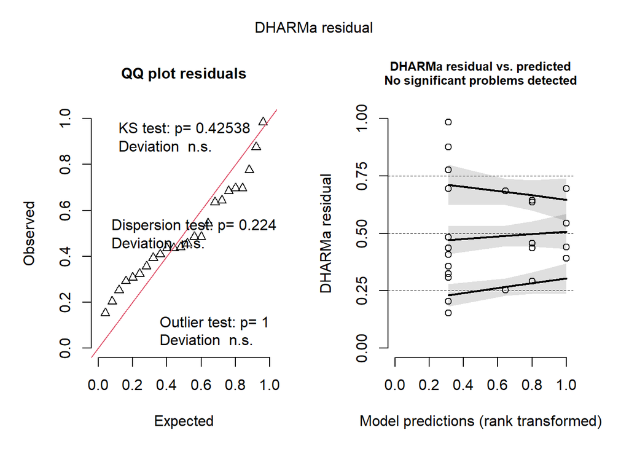

```r
# pH simulated residuals plot
calcium_ambient_simres_plot <- simulateResiduals(fittedModel = calcium_ambient_lmer)
plot(calcium_ambient_simres_plot)
```

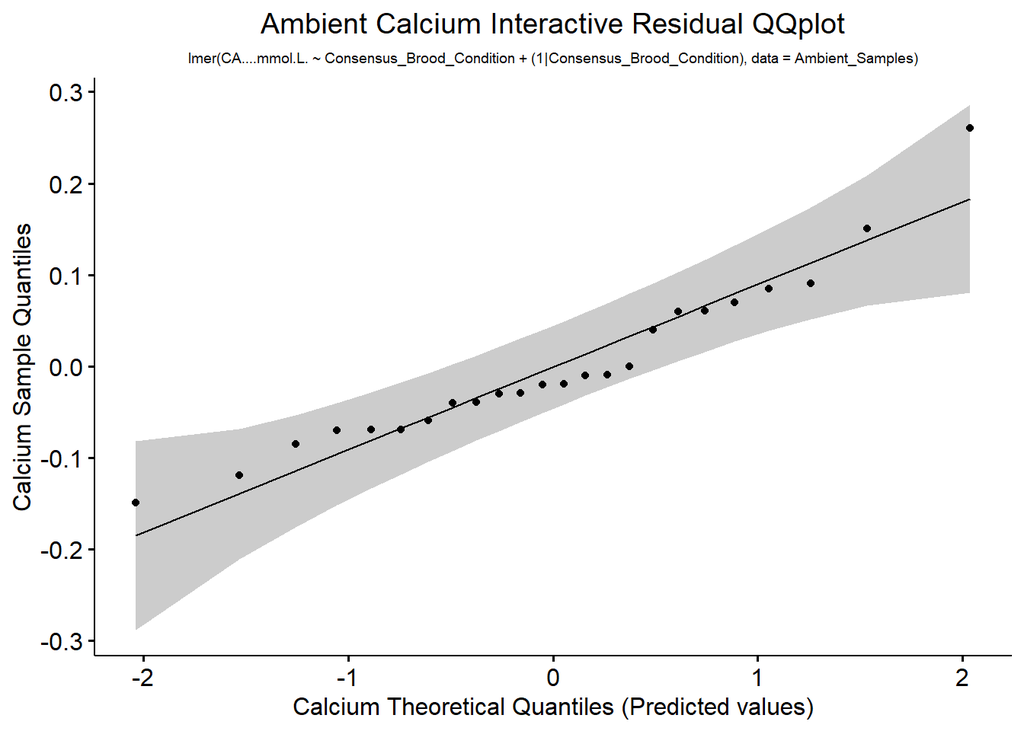

```r
# Qqplot of model
calcium_ambient_res_qqplot <- ggqqplot(residuals(calcium_ambient_lmer)) +
labs(title = "Ambient Calcium Interactive Residual QQplot",
     subtitle = "lmer(CA....mmol.L. ~ Consensus_Brood_Condition + (1|Consensus_Brood_Condition), data = Ambient_Samples)",
                               x = "Calcium Theoretical Quantiles (Predicted values)",
                               y = "Calcium Sample Quantiles") +
  theme(plot.title = element_text(hjust = 0.5),
        plot.subtitle = element_text(hjust = 0.5, size = 7))
print(calcium_ambient_res_qqplot)
```

```r
# ggsave(filename = "data-images/calcium_ambient_res_int_qqplot.pdf", plot = calcium_ambient_res_int_qqplot, device = "pdf")
# ggsave(filename = "data-images/calcium_ambient_res_int_qqplot.png", plot = calcium_ambient_res_int_qqplot, device = "png")
```

Calcium Parametric Assessment Testing Scedasticity:

```r
# Ca+2

# Ambient samples

# test with lmer
bartlett.test(calcium_ambient_res_lmer ~ Ambient_Samples$Consensus_Brood_Condition)
```

```
##
##  Bartlett test of homogeneity of variances
##
## data:  calcium_ambient_res_lmer by Ambient_Samples$Consensus_Brood_Condition
## Bartlett's K-squared = 4.0509, df = 3, p-value = 0.256
```

```r
bartlett.test(Ca....mmol.L. ~ Consensus_Brood_Condition, Ambient_Samples)
```

```
##
##  Bartlett test of homogeneity of variances
##
## data:  Ca....mmol.L. by Consensus_Brood_Condition
## Bartlett's K-squared = 4.0509, df = 3, p-value = 0.256
```

```r
# leveneTest(Ca....mmol.L. ~ Consensus_Brood_Condition, Ambient_Samples)
```

Calcium Parametric Assumptions Assessment:

Warning: Check after assessing outliers

- Ambient Data normally distributed?
- Ambient Data equal variance across factors?

# Ca+2 Stat Tests

```r
# Ca+2
# Ambient ANOVA Test

# Testing for differences in ambient parturition success metrics
# One-way ANOVA (parametric) or Kruskal-Wallis test (nonparametric)

calcium_aov_ambient <- aov(Ca....mmol.L. ~ Consensus_Brood_Condition, data = Ambient_Samples)
summary(calcium_aov_ambient)
```

```
##                           Df Sum Sq Mean Sq F value Pr(>F)
## Consensus_Brood_Condition  3 0.1120 0.03735   3.983 0.0224 *
## Residuals                 20 0.1875 0.00938
## ---
## Signif. codes:  0 '***' 0.001 '**' 0.01 '*' 0.05 '.' 0.1 ' ' 1
```

```r
# If significant, Post Hoc Test:
# - Tukey's HSD (parametric, normality & equal variance across groups)
# - Dunn's test (non-parametric, after Kruskal-Wallis test)

TukeyHSD(calcium_aov_ambient)
```

```
##   Tukey multiple comparisons of means
##     95% family-wise confidence level
##
## Fit: aov(formula = Ca....mmol.L. ~ Consensus_Brood_Condition, data = Ambient_Samples)
##
## $Consensus_Brood_Condition
##                         diff        lwr         upr     p adj
## Normal-Excellent   0.0450000 -0.1897244  0.27972441 0.9490508
## Low-Excellent      0.0050000 -0.2217653  0.23176532 0.9999126
## Atresia-Excellent -0.1157692 -0.3216362  0.09009769 0.4150154
## Low-Normal        -0.0400000 -0.2218167  0.14181674 0.9258469
## Atresia-Normal    -0.1607692 -0.3157402 -0.00579824 0.0402922
## Atresia-Low       -0.1207692 -0.2633980  0.02185956 0.1157000
```

Calcium Ambient Results

Which brood condition significantly different (if any)?